# 04.b.CU_spatial_modeling_revised

```r
library(ggplot2)
library(tidyverse)
library(terra)
library(mgcv)
library(gratia)
library(glmnet)
library(broom)
library(GGally)
library(sf)
library(tibble)
```

# Introduction

Here we’re exploring how the inclusion of evolutionary information, in the form of AU grouping, improves our modeling. There’s a couple steps here: 1. explore the data to generally look at if trends seems to vary across AUs 2. try and figure out what the best predictors are, aka what should we include in the model 3. test different hierarchical GAM models

Using K=3 AU’s for this, based on the results of an GEA. # Initial Data visualization

```r
data <- read.csv("../scratch/spatial_predictors/spatial_predictor_data_xy_from_AU_K3_threshold55.csv") %>% rename(AU=ESU)

#only data where I had a good ESU assignment
clean.data <- data %>% filter(!is.na(AU))
nrow(clean.data)
```

```
## [1] 4055
```

```r
clean.data$AU <- factor(clean.data$AU)

table(clean.data$AU)
```

```
##
##  AU1  AU2  AU3
##  782  754 2519
```

# Null model

So this is our null model with just the range wide environmental stuff. The goal here is to get the parameter k to the best value. K in this context is the maximum basis dimension allowed for the GAM smooth. We want to play with the K values until we get a k-index close to 1, a p-value that > 0.5, and a EDF that’s not super close to the k value (suggesting we’re capping the effective degrees of freedom too low, aka it wants to be wigglier).

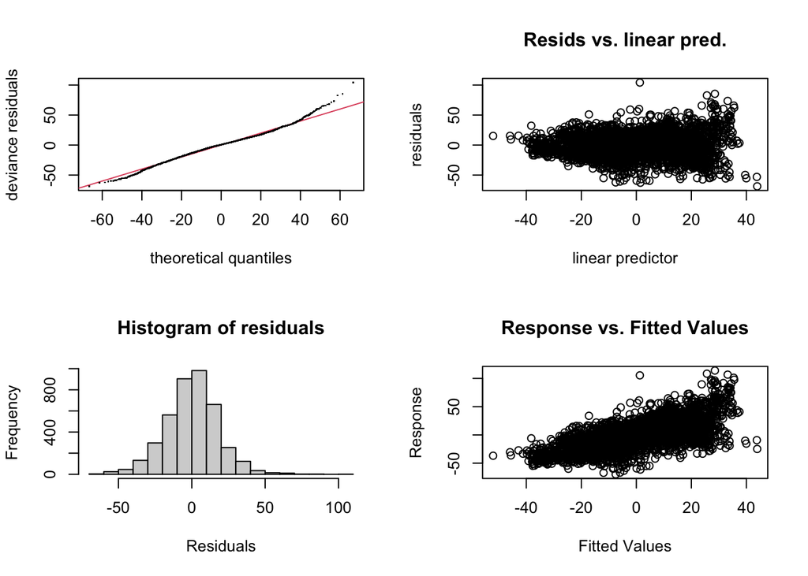

```
##
## Method: REML   Optimizer: outer newton
## full convergence after 8 iterations.
## Gradient range [-0.000164507,8.070396e-05]
## (score 17605.97 & scale 330.4139).
## Hessian positive definite, eigenvalue range [3.991518,2025.066].
## Model rank =  57 / 57
##
## Basis dimension (k) checking results. Low p-value (k-index<1) may
## indicate that k is too low, especially if edf is close to k'.
##
##                      k'  edf k-index p-value
## s(ppt_june_delta)  14.0 12.5    0.99   0.170
## s(soil_june_delta) 14.0 12.5    0.95  <2e-16 ***
## s(tmax_june_delta) 14.0 11.9    1.00   0.545
## s(tmin_june_delta) 14.0 13.3    0.97   0.005 **
## ---
## Signif. codes:  0 '***' 0.001 '**' 0.01 '*' 0.05 '.' 0.1 ' ' 1
```

```r
gam_null <- gam(abd_trend ~ s(ppt_june_delta, k = 15, bs="tp") + s(soil_june_delta, k = 15, bs="tp") + s(tmax_june_delta, k = 15, bs="tp") + s(tmin_june_delta, k = 15, bs="tp"), data=clean.data, method="REML")

mgcv::gam.check(gam_null)
```

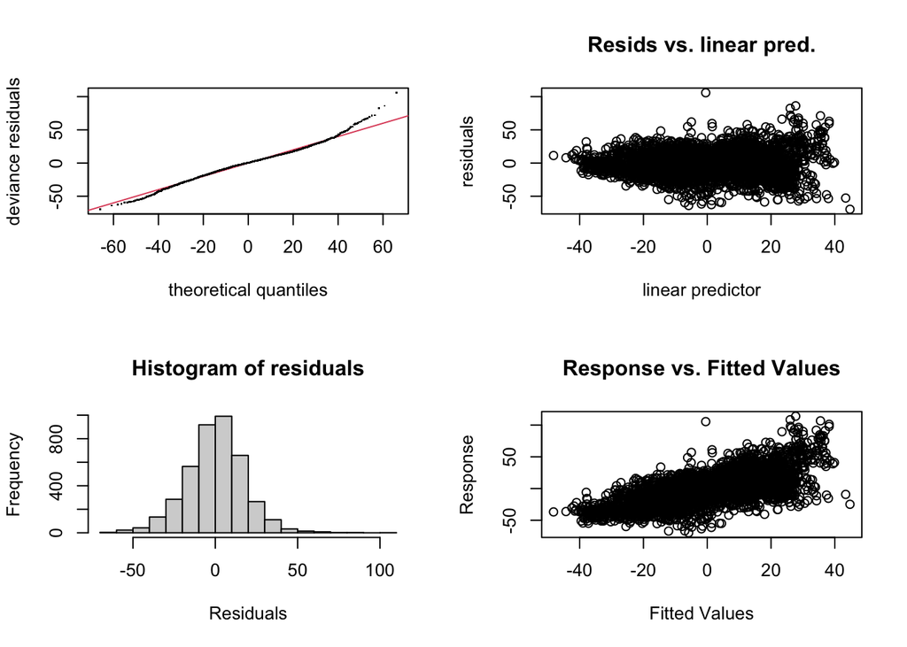

```
##
## Method: REML   Optimizer: outer newton
## full convergence after 6 iterations.
## Gradient range [-8.540489e-05,3.52465e-05]
## (score 17584.31 & scale 324.1021).
## Hessian positive definite, eigenvalue range [3.999825,2025.103].
## Model rank =  72 / 72
##
## Basis dimension (k) checking results. Low p-value (k-index<1) may
## indicate that k is too low, especially if edf is close to k'.
##
##                      k'  edf k-index p-value
## s(ppt_june_delta)  19.0 16.2    1.00   0.525
## s(soil_june_delta) 19.0 16.0    0.96  <2e-16 ***
## s(tmax_june_delta) 14.0 11.9    1.00   0.540
## s(tmin_june_delta) 19.0 17.0    0.97   0.055 .
## ---
## Signif. codes:  0 '***' 0.001 '**' 0.01 '*' 0.05 '.' 0.1 ' ' 1
```

```r
# tmax looks good here but the rest would be better I think

gam_null <- gam(abd_trend ~ s(ppt_june_delta, k = 20, bs="tp") + s(soil_june_delta, k = 20, bs="tp") + s(tmax_june_delta, k = 15, bs="tp") + s(tmin_june_delta, k = 20, bs="tp"), data=clean.data, method="REML")

mgcv::gam.check(gam_null)
```

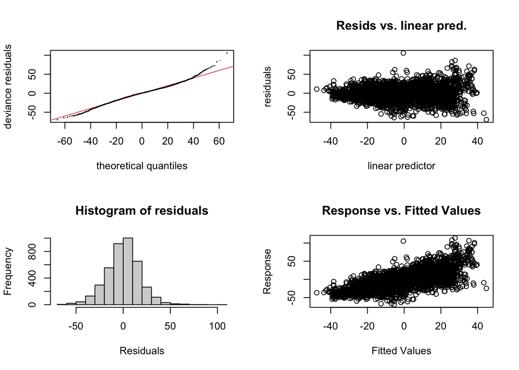

```
##
## Method: REML   Optimizer: outer newton
## full convergence after 5 iterations.
## Gradient range [-0.01157552,0.001162049]
## (score 17585.05 & scale 323.9984).
## Hessian positive definite, eigenvalue range [3.998882,2025.129].
## Model rank =  82 / 82
##
## Basis dimension (k) checking results. Low p-value (k-index<1) may
## indicate that k is too low, especially if edf is close to k'.
##
##                      k'  edf k-index p-value
## s(ppt_june_delta)  19.0 16.2    1.00   0.460
## s(soil_june_delta) 24.0 17.5    0.96  <2e-16 ***
## s(tmax_june_delta) 14.0 11.9    1.00   0.570
## s(tmin_june_delta) 24.0 19.1    0.97   0.055 .
## ---
## Signif. codes:  0 '***' 0.001 '**' 0.01 '*' 0.05 '.' 0.1 ' ' 1
```

```r
# ppt is better here, doesn't seem constrainted and k-index and p-values are good

gam_null <- gam(abd_trend ~ s(ppt_june_delta, k = 20, bs="tp") + s(soil_june_delta, k = 25, bs="tp") + s(tmax_june_delta, k = 15, bs="tp") + s(tmin_june_delta, k = 25, bs="tp"), data=clean.data, method="REML")

mgcv::gam.check(gam_null)
```

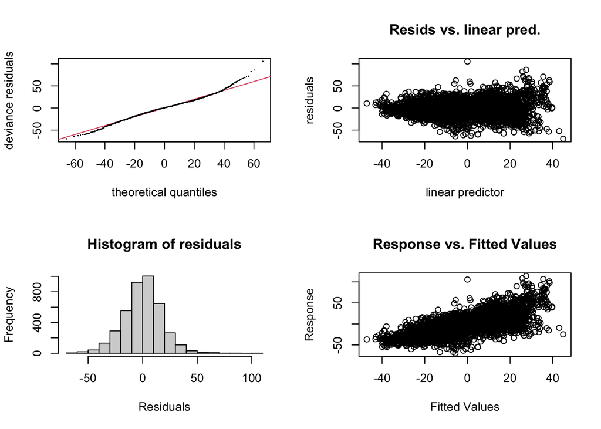

```
##
## Method: REML   Optimizer: outer newton
## full convergence after 8 iterations.
## Gradient range [-0.002091231,0.0006205091]
## (score 17583.75 & scale 323.3022).
## Hessian positive definite, eigenvalue range [4.001351,2025.133].
## Model rank =  92 / 92
##
## Basis dimension (k) checking results. Low p-value (k-index<1) may
## indicate that k is too low, especially if edf is close to k'.
##
##                      k'  edf k-index p-value
## s(ppt_june_delta)  19.0 16.2    1.00    0.42
## s(soil_june_delta) 29.0 19.1    0.96    0.01 **
## s(tmax_june_delta) 14.0 11.9    1.00    0.52
## s(tmin_june_delta) 29.0 20.4    0.97    0.04 *
## ---
## Signif. codes:  0 '***' 0.001 '**' 0.01 '*' 0.05 '.' 0.1 ' ' 1
```

```r
gam_null <- gam(abd_trend ~ s(ppt_june_delta, k = 20, bs="tp") + s(soil_june_delta, k = 30, bs="tp") + s(tmax_june_delta, k = 15, bs="tp") + s(tmin_june_delta, k = 30, bs="tp"), data=clean.data, method="REML")

mgcv::gam.check(gam_null)
```

So, the EDF seems to be stopping instead but soil and Tmin are still not super happy, so lets look at some other stuff.

“Basis dimensions were increased until smooth EDFs were comfortably below their maximum available dimensions. Remaining low k-index values were therefore evaluated as potential residual/model structure rather than evidence for further increasing basis size.”

```r
gam_null <- gam(abd_trend ~ s(ppt_june_delta, k = 20, bs="tp") + s(soil_june_delta, k = 25, bs="tp") + s(tmax_june_delta, k = 15, bs="tp") + s(tmin_june_delta, k = 25, bs="tp"), data=clean.data, method="REML")
concurvity(gam_null, full = TRUE)
```

```
##                  para s(ppt_june_delta) s(soil_june_delta) s(tmax_june_delta)
## worst    8.795747e-25         0.6382589          0.6652018          0.8380684
## observed 8.795747e-25         0.2288114          0.3124648          0.6509469
## estimate 8.795747e-25         0.5080088          0.5569991          0.7165852
##          s(tmin_june_delta)
## worst             0.8528404
## observed          0.5013217
## estimate          0.7586952
```

Concurvity is tackling multicollinearity, which it’s reasonable to think there will be give that these are all environmental variables. Above 0.7 is the threshold we’re worried about it. Observed and estimate are probably the most useful things here. No shocker, the Tmin and Tmax are showing the higher values here. Let’s play around with removing one of these variables at a time…

```r
gam_no_tmax <- gam(
  abd_trend ~
    s(ppt_june_delta,  k = 20, bs = "tp") +
    s(soil_june_delta, k = 25, bs = "tp") +
    s(tmin_june_delta, k = 25, bs = "tp"),
  data = clean.data,
  method = "REML"
)

gam_no_tmin <- gam(
  abd_trend ~
    s(ppt_june_delta,  k = 20, bs = "tp") +
    s(soil_june_delta, k = 25, bs = "tp") +
    s(tmax_june_delta, k = 15, bs = "tp"),
  data = clean.data,
  method = "REML"
)

AIC(gam_null, gam_no_tmax, gam_no_tmin)
```

```
##                   df      AIC
## gam_null    68.64701 35019.55
## gam_no_tmax 54.89829 35926.61
## gam_no_tmin 50.88250 35287.12
```

```r
summary(gam_null)$dev.expl
```

```
## [1] 0.4512331
```

```r
summary(gam_no_tmax)$dev.expl
```

```
## [1] 0.3089976
```

```r
summary(gam_no_tmin)$dev.expl
```

```
## [1] 0.4086427
```

So, keeping the terms does keep the model stronger, which suggests we don’t really need to drop a variable just be a little cautious about interpreting the temperature variables independently of the rest.

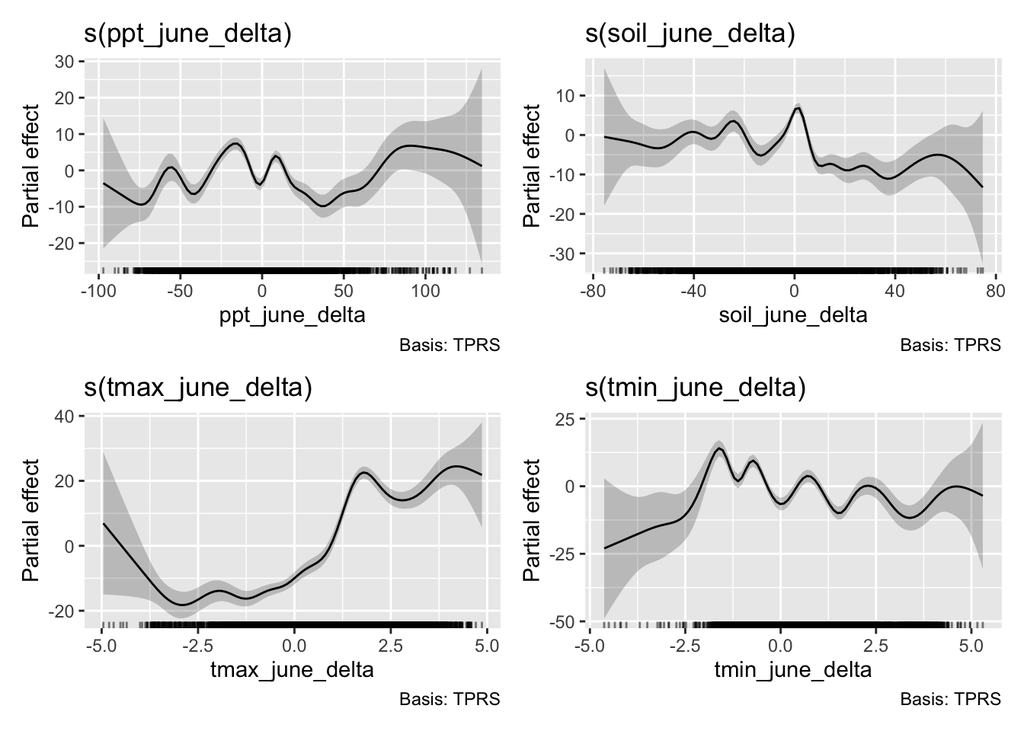

```r
draw(gam_null)
```

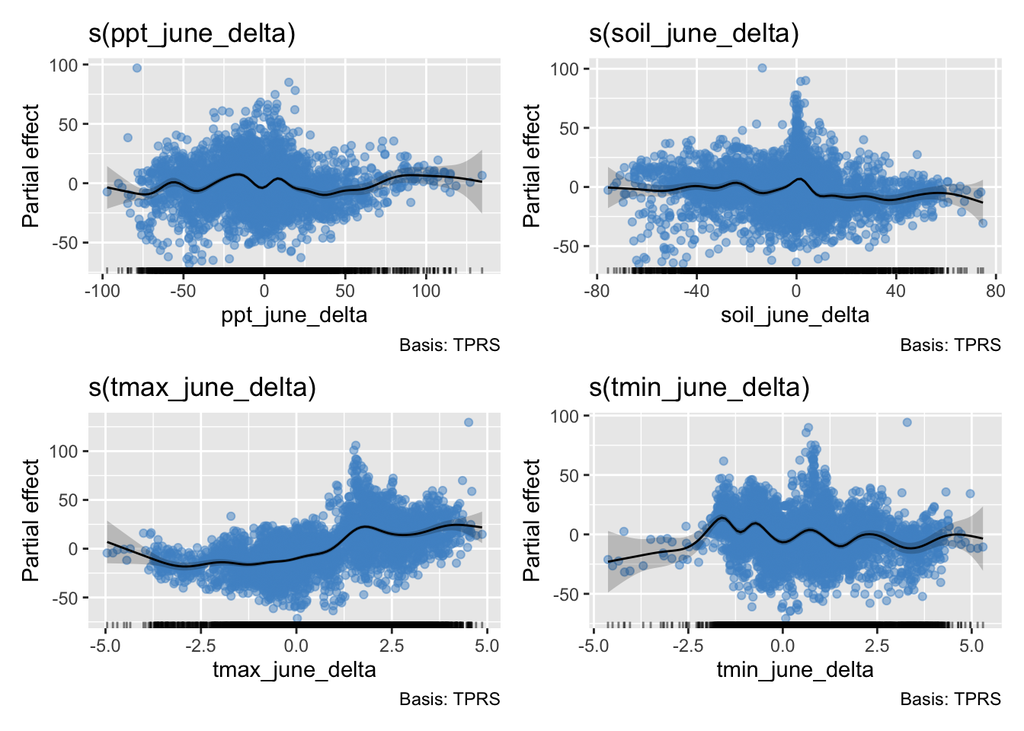

```r
draw(gam_null, residuals = TRUE)
```

Worried about spatial autocorrelation…

```r
library(sf)
library(spdep)
pts <- st_as_sf(
  clean.data,
  coords = c("x", "y"),
  crs = 4326
)

# better to work in a projected CRS for distance-based neighbors
pts_proj <- st_transform(pts, 5070)  # Albers Equal Area for CONUS

coords <- st_coordinates(pts_proj)

# e.g. neighbors within ~40 km
nb <- dnearneigh(coords, d1 = 0, d2 = 40000)
lw <- nb2listw(nb, style = "W", zero.policy = TRUE)

moran.test(
  residuals(gam_null),
  lw,
  zero.policy = TRUE
)
```

```
##
##  Moran I test under randomisation
##
## data:  residuals(gam_null)
## weights: lw
## n reduced by no-neighbour observations
##
## Moran I statistic standard deviate = 67.562, p-value < 2.2e-16
## alternative hypothesis: greater
## sample estimates:
## Moran I statistic       Expectation          Variance
##      0.7541685396     -0.0002526529      0.0001246872
```

Whoops, super high. Let’s try adding spatial stuff to the model.

```r
# gam_spatial <- gam(
#   abd_trend ~
#     s(ppt_june_delta,  k = 20, bs = "tp") +
#     s(soil_june_delta, k = 25, bs = "tp") +
#     s(tmax_june_delta, k = 15, bs = "tp") +
#     s(tmin_june_delta, k = 25, bs = "tp") +
#     s(x, y, k = 100, bs = "tp"),
#   data = clean.data,
#   method = "REML"
# )

# saveRDS(gam_spatial, "../scratch/model_storage/gam_spatial")
gam_spatial <- readRDS("../scratch/model_storage/gam_spatial")

summary(gam_spatial)
```

```
##
## Family: gaussian
## Link function: identity
##
## Formula:
## abd_trend ~ s(ppt_june_delta, k = 20, bs = "tp") + s(soil_june_delta,
##     k = 25, bs = "tp") + s(tmax_june_delta, k = 15, bs = "tp") +
##     s(tmin_june_delta, k = 25, bs = "tp") + s(x, y, k = 100,
##     bs = "tp")
##
## Parametric coefficients:
##             Estimate Std. Error t value Pr(>|t|)
## (Intercept)   1.4646     0.1591   9.208   <2e-16 ***
## ---
## Signif. codes:  0 '***' 0.001 '**' 0.01 '*' 0.05 '.' 0.1 ' ' 1
##
## Approximate significance of smooth terms:
##                       edf Ref.df      F  p-value
## s(ppt_june_delta)   9.859 12.269  3.699 1.03e-05 ***
## s(soil_june_delta)  1.624  2.054  1.057    0.342
## s(tmax_june_delta) 10.916 12.651  8.127  < 2e-16 ***
## s(tmin_june_delta) 15.305 18.585  3.123 8.12e-06 ***
## s(x,y)             94.144 98.395 99.886  < 2e-16 ***
## ---
## Signif. codes:  0 '***' 0.001 '**' 0.01 '*' 0.05 '.' 0.1 ' ' 1
##
## R-sq.(adj) =  0.823   Deviance explained = 82.9%
## -REML =  15392  Scale est. = 102.59    n = 4055
```

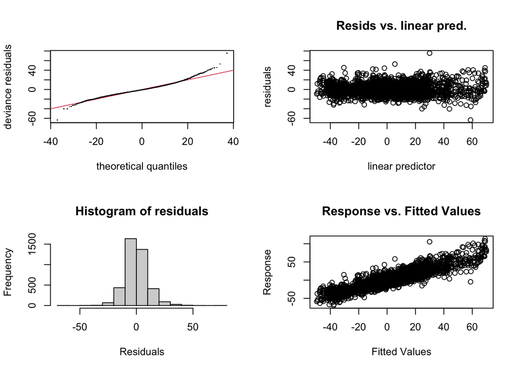

```
##
## Method: REML   Optimizer: outer newton
## full convergence after 8 iterations.
## Gradient range [-0.004108963,0.002491912]
## (score 15391.7 & scale 102.5871).
## Hessian positive definite, eigenvalue range [0.1223688,2025.113].
## Model rank =  181 / 181
##
## Basis dimension (k) checking results. Low p-value (k-index<1) may
## indicate that k is too low, especially if edf is close to k'.
##
##                       k'   edf k-index p-value
## s(ppt_june_delta)  19.00  9.86    1.00   0.585
## s(soil_june_delta) 24.00  1.62    0.95   0.015 *
## s(tmax_june_delta) 14.00 10.92    1.01   0.610
## s(tmin_june_delta) 24.00 15.31    0.98   0.105
## s(x,y)             99.00 94.14    0.56  <2e-16 ***
## ---
## Signif. codes:  0 '***' 0.001 '**' 0.01 '*' 0.05 '.' 0.1 ' ' 1
```

```r
gam.check(gam_spatial)
```

```r
spdep::moran.test(
  residuals(gam_spatial),
  lw,
  zero.policy = TRUE
)
```

```
##
##  Moran I test under randomisation
##
## data:  residuals(gam_spatial)
## weights: lw
## n reduced by no-neighbour observations
##
## Moran I statistic standard deviate = 37.459, p-value < 2.2e-16
## alternative hypothesis: greater
## sample estimates:
## Moran I statistic       Expectation          Variance
##      0.4179549599     -0.0002526529      0.0001246461
```

So, the spatial variables are super important but we retain the climate variables too, which is good. Deviance explained shoots up a ton, which makes sense. The k value for x.y is way too low, so gotta crank that up. Let’s see how much spatial autocorrelation is left though. Also, looks like I might end up wanting to drop soil, it basically fell away as important.

```r
# gam_spatial2 <- gam(
#   abd_trend ~
#     s(ppt_june_delta,  k = 20, bs = "tp") +
#     s(soil_june_delta, k = 25, bs = "tp") +
#     s(tmax_june_delta, k = 15, bs = "tp") +
#     s(tmin_june_delta, k = 25, bs = "tp") +
#     s(x, y, k = 300, bs = "tp"),
#   data = clean.data,
#   method = "REML"
# )
#
# saveRDS(gam_spatial2, "../scratch/model_storage/gam_spatial2")
gam_spatial2 <- readRDS("../scratch/model_storage/gam_spatial2")

summary(gam_spatial2)
```

```
##
## Family: gaussian
## Link function: identity
##
## Formula:
## abd_trend ~ s(ppt_june_delta, k = 20, bs = "tp") + s(soil_june_delta,
##     k = 25, bs = "tp") + s(tmax_june_delta, k = 15, bs = "tp") +
##     s(tmin_june_delta, k = 25, bs = "tp") + s(x, y, k = 300,
##     bs = "tp")
##
## Parametric coefficients:
##             Estimate Std. Error t value Pr(>|t|)
## (Intercept)   1.4646     0.1362   10.75   <2e-16 ***
## ---
## Signif. codes:  0 '***' 0.001 '**' 0.01 '*' 0.05 '.' 0.1 ' ' 1
##
## Approximate significance of smooth terms:
##                        edf  Ref.df      F p-value
## s(ppt_june_delta)    4.746   6.184  2.293  0.0289 *
## s(soil_june_delta)   1.002   1.003  1.305  0.2531
## s(tmax_june_delta)  12.635  13.619  6.786  <2e-16 ***
## s(tmin_june_delta)  18.260  21.285  4.501  <2e-16 ***
## s(x,y)             258.737 288.589 52.410  <2e-16 ***
## ---
## Signif. codes:  0 '***' 0.001 '**' 0.01 '*' 0.05 '.' 0.1 ' ' 1
##
## R-sq.(adj) =  0.871   Deviance explained =   88%
## -REML =  15015  Scale est. = 75.212    n = 4055
```

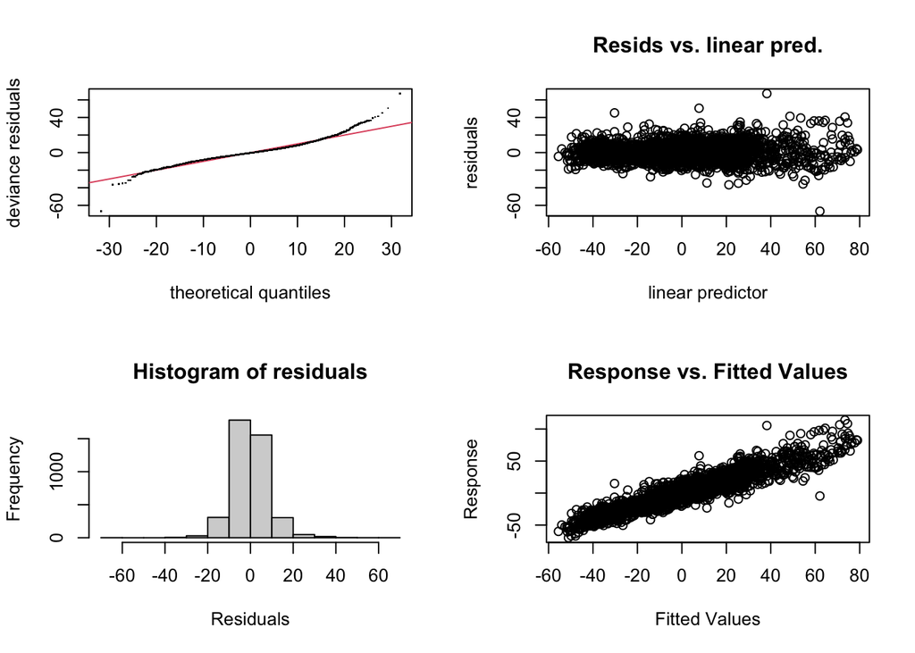

```
##
## Method: REML   Optimizer: outer newton
## full convergence after 8 iterations.
## Gradient range [-0.0004358141,9.217578e-07]
## (score 15015.05 & scale 75.21166).
## Hessian positive definite, eigenvalue range [0.0004352036,2032.563].
## Model rank =  381 / 381
##
## Basis dimension (k) checking results. Low p-value (k-index<1) may
## indicate that k is too low, especially if edf is close to k'.
##
##                        k'    edf k-index p-value
## s(ppt_june_delta)   19.00   4.75    1.00    0.59
## s(soil_june_delta)  24.00   1.00    0.96    0.01 **
## s(tmax_june_delta)  14.00  12.64    1.01    0.69
## s(tmin_june_delta)  24.00  18.26    0.97    0.04 *
## s(x,y)             299.00 258.74    0.74  <2e-16 ***
## ---
## Signif. codes:  0 '***' 0.001 '**' 0.01 '*' 0.05 '.' 0.1 ' ' 1
```

```r
gam.check(gam_spatial2)
```

```r
spdep::moran.test(
  residuals(gam_spatial2),
  lw,
  zero.policy = TRUE
)
```

```
##
##  Moran I test under randomisation
##
## data:  residuals(gam_spatial2)
## weights: lw
## n reduced by no-neighbour observations
##
## Moran I statistic standard deviate = 21.298, p-value < 2.2e-16
## alternative hypothesis: greater
## sample estimates:
## Moran I statistic       Expectation          Variance
##      0.2374838545     -0.0002526529      0.0001245937
```

Getting better…. still needs more space… also soil is still not relevant. Let’s crank K for x.y. Also noting that tmin is being funky, but when plotting the spatial versus spatial 2, the tmin gains complexity that I think is actually useful for interpretation. I don’t think I’m reasonably going to get to a K where x.y is totally happy, but if I can find a spot where the other k’s are stablizing in their complexity that might suggest that i’m doing a good enough job of accounting for spatial complexity in that the variables i’m more interested in can shine through. There’s also certainly a computation limit here where raising the k for x.y makes this run wayyyy slower.

```r
# gam_spatial3 <- gam(
#   abd_trend ~
#     s(ppt_june_delta,  k = 20, bs = "tp") +
#     s(soil_june_delta, k = 25, bs = "tp") +
#     s(tmax_june_delta, k = 15, bs = "tp") +
#     s(tmin_june_delta, k = 25, bs = "tp") +
#     s(x, y, k = 500, bs = "tp"),
#   data = clean.data,
#   method = "REML"
# )
#
# saveRDS(gam_spatial3, "../scratch/model_storage/gam_spatial3")
gam_spatial3 <- readRDS("../scratch/model_storage/gam_spatial3")

summary(gam_spatial3)
```

```
##
## Family: gaussian
## Link function: identity
##
## Formula:
## abd_trend ~ s(ppt_june_delta, k = 20, bs = "tp") + s(soil_june_delta,
##     k = 25, bs = "tp") + s(tmax_june_delta, k = 15, bs = "tp") +
##     s(tmin_june_delta, k = 25, bs = "tp") + s(x, y, k = 500,
##     bs = "tp")
##
## Parametric coefficients:
##             Estimate Std. Error t value Pr(>|t|)
## (Intercept)   1.4646     0.1243   11.78   <2e-16 ***
## ---
## Signif. codes:  0 '***' 0.001 '**' 0.01 '*' 0.05 '.' 0.1 ' ' 1
##
## Approximate significance of smooth terms:
##                        edf  Ref.df      F p-value
## s(ppt_june_delta)    3.425   4.476  1.625   0.163
## s(soil_june_delta)   1.002   1.003  1.531   0.216
## s(tmax_june_delta)  11.657  13.012  3.988 2.2e-06 ***
## s(tmin_june_delta)  18.172  21.132  4.170 < 2e-16 ***
## s(x,y)             404.468 467.075 40.726 < 2e-16 ***
## ---
## Signif. codes:  0 '***' 0.001 '**' 0.01 '*' 0.05 '.' 0.1 ' ' 1
##
## R-sq.(adj) =  0.892   Deviance explained = 90.4%
## -REML =  14841  Scale est. = 62.646    n = 4055
```

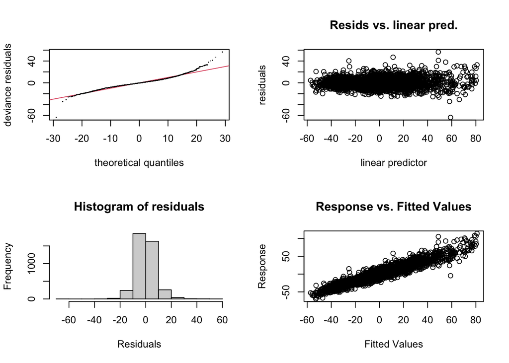

```
##
## Method: REML   Optimizer: outer newton
## full convergence after 9 iterations.
## Gradient range [-0.008720373,1.702822e-05]
## (score 14840.62 & scale 62.64608).
## Hessian positive definite, eigenvalue range [0.0006568406,2045.25].
## Model rank =  581 / 581
##
## Basis dimension (k) checking results. Low p-value (k-index<1) may
## indicate that k is too low, especially if edf is close to k'.
##
##                        k'    edf k-index p-value
## s(ppt_june_delta)   19.00   3.42    1.01   0.630
## s(soil_june_delta)  24.00   1.00    0.98   0.100 .
## s(tmax_june_delta)  14.00  11.66    1.01   0.675
## s(tmin_june_delta)  24.00  18.17    0.97   0.015 *
## s(x,y)             499.00 404.47    0.85  <2e-16 ***
## ---
## Signif. codes:  0 '***' 0.001 '**' 0.01 '*' 0.05 '.' 0.1 ' ' 1
```

```r
gam.check(gam_spatial3)
```

```r
spdep::moran.test(
  residuals(gam_spatial3),
  lw,
  zero.policy = TRUE
)
```

```
##
##  Moran I test under randomisation
##
## data:  residuals(gam_spatial3)
## weights: lw
## n reduced by no-neighbour observations
##
## Moran I statistic standard deviate = 12.234, p-value < 2.2e-16
## alternative hypothesis: greater
## sample estimates:
## Moran I statistic       Expectation          Variance
##      0.1363057273     -0.0002526529      0.0001245950
```

```
             spatial k=100 spatial k=300    spatial k=500
```

```
               df      AIC
```

This spatial3 is looking really good. I could technically keep increasing the k from 500 because it’s asking for more flexibility but I don’t think it’s entirely necessary. The Moran’s I has gone down a ton, the other variables are stabilizing and it’s become clear which variables aren’t important anymore. Acklowedging that spatial autocorrelation and k-index is still significant, I’m settling on this model.

## spatial auto checks

So, let’s see if we can keep the K low so it doesn’t absorb the effect of the climate so much without building a terrible model.

```r
k_vals <- c(50, 100, 200, 300, 400, 500)

# gam_k_models <- setNames(
#   lapply(k_vals, function(k_space) {
#
#     gam(
#       abd_trend ~
#         s(tmax_june_delta, k = 15, bs = "tp") +
#         s(tmin_june_delta, k = 25, bs = "tp") +
#         s(x, y, k = k_space, bs = "tp"),
#       data = clean.data,
#       method = "REML"
#     )
#
#   }),
#   paste0("k", k_vals)
# )

# saveRDS(gam_k_models, "../scratch/model_storage/gam_k_models")
gam_k_models <- readRDS("../scratch/model_storage/gam_k_models")

model_summary <- map_dfr(
  names(gam_k_models),
  function(nm) {

    mod <- gam_k_models[[nm]]
    sm  <- summary(mod)

    tibble(
      model = nm,
      spatial_k = as.numeric(sub("k", "", nm)),
      AIC = AIC(mod),
      logLik = as.numeric(logLik(mod)),
      df = attr(logLik(mod), "df"),
      deviance_explained = sm$dev.expl,
      adjusted_r2 = sm$r.sq
    )
  }
)

model_summary
```

```
## # A tibble: 6 × 7
##   model spatial_k    AIC  logLik    df deviance_explained adjusted_r2
##   <chr>     <dbl>  <dbl>   <dbl> <dbl>              <dbl>       <dbl>
## 1 k50          50 31185. -15515.  76.8              0.788       0.784
## 2 k100        100 30455. -15101. 127.               0.827       0.822
## 3 k200        200 29875. -14725. 212.               0.856       0.848
## 4 k300        300 29327. -14369. 294.               0.879       0.870
## 5 k400        400 29029. -14148. 366.               0.892       0.881
## 6 k500        500 28708. -13914. 440.               0.904       0.892
```

```r
edf_summary <- map_dfr(
  names(gam_k_models),
  function(nm) {

    mod <- gam_k_models[[nm]]
    s <- summary(mod)$s.table

    tibble(
      model = nm,
      spatial_k = as.numeric(sub("k", "", nm)),
      term = rownames(s),
      edf = s[, "edf"],
      ref_df = s[, "Ref.df"],
      p_value = s[, ncol(s)]
    )
  }
)

edf_summary
```

```
## # A tibble: 18 × 6
##    model spatial_k term                 edf ref_df    p_value
##    <chr>     <dbl> <chr>              <dbl>  <dbl>      <dbl>
##  1 k50          50 s(tmax_june_delta)  10.2   12.0 0
##  2 k50          50 s(tmin_june_delta)  15.6   18.7 0
##  3 k50          50 s(x,y)              47.2   48.8 0
##  4 k100        100 s(tmax_june_delta)  10.5   12.4 0
##  5 k100        100 s(tmin_june_delta)  17.1   20.3 0.00000368
##  6 k100        100 s(x,y)              94.4   98.5 0
##  7 k200        200 s(tmax_june_delta)  12.2   13.4 0
##  8 k200        200 s(tmin_june_delta)  19.0   21.9 0
##  9 k200        200 s(x,y)             177.   194.  0
## 10 k300        300 s(tmax_june_delta)  12.6   13.6 0
## 11 k300        300 s(tmin_june_delta)  18.6   21.6 0
## 12 k300        300 s(x,y)             259.   289.  0
## 13 k400        400 s(tmax_june_delta)  12.3   13.4 0
## 14 k400        400 s(tmin_june_delta)  18.8   21.6 0
## 15 k400        400 s(x,y)             331.   378.  0
## 16 k500        500 s(tmax_june_delta)  11.6   13.0 0.00000262
## 17 k500        500 s(tmin_june_delta)  18.2   21.2 0
## 18 k500        500 s(x,y)             406.   468.  0
```

```r
concurvity_summary <- map_dfr(
  names(gam_k_models),
  function(nm) {

    mod <- gam_k_models[[nm]]

    cc <- concurvity(mod, full = TRUE)

    tibble(
      model = nm,
      spatial_k = as.numeric(sub("k", "", nm)),

      tmax_observed =
        cc["observed", "s(tmax_june_delta)"],

      tmin_observed =
        cc["observed", "s(tmin_june_delta)"],

      space_observed =
        cc["observed", "s(x,y)"],

      tmax_estimate =
        cc["estimate", "s(tmax_june_delta)"],

      tmin_estimate =
        cc["estimate", "s(tmin_june_delta)"],

      space_estimate =
        cc["estimate", "s(x,y)"]
    )
  }
)

concurvity_summary
```

```
## # A tibble: 6 × 8
##   model spatial_k tmax_observed tmin_observed space_observed tmax_estimate
##   <chr>     <dbl>         <dbl>         <dbl>          <dbl>         <dbl>
## 1 k50          50         0.811         0.860          0.309         0.960
## 2 k100        100         0.923         0.973          0.402         0.975
## 3 k200        200         0.974         0.983          0.445         0.986
## 4 k300        300         0.968         0.977          0.409         0.990
## 5 k400        400         0.983         0.980          0.440         0.993
## 6 k500        500         0.990         0.983          0.454         0.994
## # ℹ 2 more variables: tmin_estimate <dbl>, space_estimate <dbl>
```

```r
pairwise_concurvity <- lapply(
  gam_k_models,
  concurvity,
  full = FALSE
)

kcheck_summary <- map_dfr(
  names(gam_k_models),
  function(nm) {

    mod <- gam_k_models[[nm]]

    kc <- k.check(mod)

    as.data.frame(kc) %>%
      rownames_to_column("term") %>%
      mutate(
        model = nm,
        spatial_k = as.numeric(sub("k", "", nm))
      ) %>%
      select(
        model,
        spatial_k,
        term,
        everything()
      )
  }
)

kcheck_summary
```

```
##    model spatial_k               term  k'       edf   k-index p-value
## 1    k50        50 s(tmax_june_delta)  14  10.18767 1.0161892  0.8575
## 2    k50        50 s(tmin_june_delta)  24  15.56290 0.9864097  0.1825
## 3    k50        50             s(x,y)  49  47.16252 0.4614725  0.0000
## 4   k100       100 s(tmax_june_delta)  14  10.50089 1.0057379  0.6000
## 5   k100       100 s(tmin_june_delta)  24  17.06248 0.9823943  0.1400
## 6   k100       100             s(x,y)  99  94.42981 0.5485560  0.0000
## 7   k200       200 s(tmax_june_delta)  14  12.20273 1.0048134  0.5575
## 8   k200       200 s(tmin_june_delta)  24  19.00795 0.9781594  0.0875
## 9   k200       200             s(x,y) 199 177.28374 0.6418697  0.0000
## 10  k300       300 s(tmax_june_delta)  14  12.62938 1.0079669  0.7250
## 11  k300       300 s(tmin_june_delta)  24  18.61148 0.9744224  0.0500
## 12  k300       300             s(x,y) 299 259.35453 0.7340606  0.0000
## 13  k400       400 s(tmax_june_delta)  14  12.33371 1.0010551  0.5775
## 14  k400       400 s(tmin_june_delta)  24  18.77494 0.9721905  0.0400
## 15  k400       400             s(x,y) 399 331.43508 0.7907548  0.0000
## 16  k500       500 s(tmax_june_delta)  14  11.60538 1.0044170  0.6375
## 17  k500       500 s(tmin_june_delta)  24  18.19629 0.9688258  0.0300
## 18  k500       500             s(x,y) 499 405.66232 0.8483715  0.0000
```

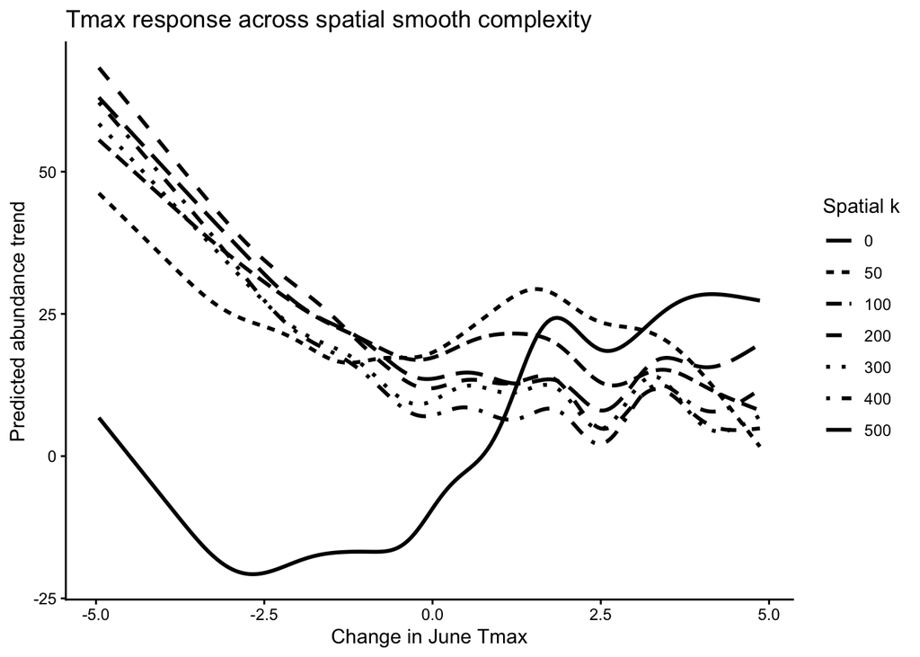

```r
# gam_nospatial <- gam(
#   abd_trend ~
#     s(tmax_june_delta, k = 15, bs = "tp") +
#     s(tmin_june_delta, k = 25, bs = "tp"),
#   data = clean.data,
#   method = "REML"
# )

#saveRDS(gam_nospatial, "../scratch/model_storage/gam_nospatial")
gam_nospatial <- readRDS("../scratch/model_storage/gam_nospatial")

get_curve <- function(mod, model_name, focal_var, data, n = 200) {

  xseq <- seq(
    min(data[[focal_var]], na.rm = TRUE),
    max(data[[focal_var]], na.rm = TRUE),
    length.out = n
  )

  newdat <- data.frame(
    tmax_june_delta = median(data$tmax_june_delta, na.rm = TRUE),
    tmin_june_delta = median(data$tmin_june_delta, na.rm = TRUE),
    x = median(data$x, na.rm = TRUE),
    y = median(data$y, na.rm = TRUE)
  )

  newdat <- newdat[rep(1, n), ]
  newdat[[focal_var]] <- xseq

  pred <- predict(
    mod,
    newdata = newdat,
    se.fit = TRUE,
    type = "response"
  )

  tibble(
    model = model_name,

    spatial_k = ifelse(
      model_name == "none",
      0,
      as.numeric(sub("k", "", model_name))
    ),

    focal_var = focal_var,
    climate_value = xseq,
    fit = as.numeric(pred$fit),
    se = as.numeric(pred$se.fit),
    lower = fit - 1.96 * se,
    upper = fit + 1.96 * se
  )
}

all_models <- c(
  list(none = gam_nospatial),
  gam_k_models
)

curve_data <- map_dfr(
  names(all_models),
  function(nm) {

    mod <- all_models[[nm]]

    bind_rows(
      get_curve(
        mod,
        model_name = nm,
        focal_var = "tmax_june_delta",
        data = clean.data
      ),
      get_curve(
        mod,
        model_name = nm,
        focal_var = "tmin_june_delta",
        data = clean.data
      )
    )
  }
)

curve_data %>%
  filter(focal_var == "tmax_june_delta") %>%
  ggplot(
    aes(
      x = climate_value,
      y = fit,
      group = factor(spatial_k),
      linetype = factor(spatial_k)
    )
  ) +
  geom_line(linewidth = 1) +
  theme_classic() +
  labs(
    x = "Change in June Tmax",
    y = "Predicted abundance trend",
    linetype = "Spatial k",
    title = "Tmax response across spatial smooth complexity"
  )
```

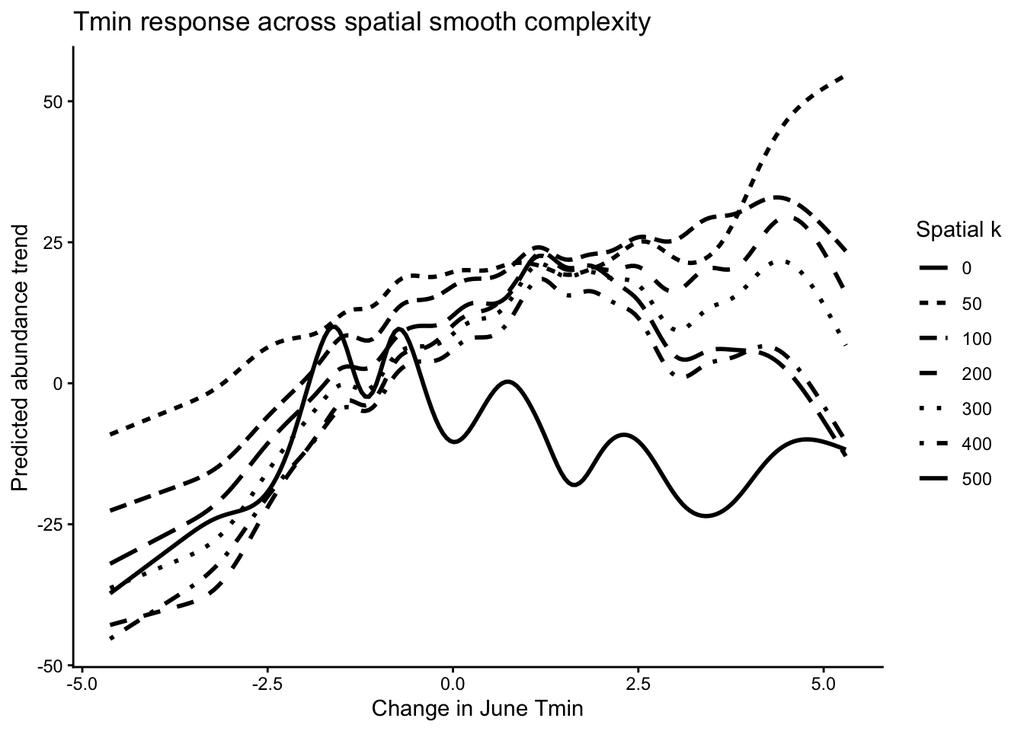

```r
curve_data %>%
  filter(focal_var == "tmin_june_delta") %>%
  ggplot(
    aes(
      x = climate_value,
      y = fit,
      group = factor(spatial_k),
      linetype = factor(spatial_k)
    )
  ) +
  geom_line(linewidth = 1) +
  theme_classic() +
  labs(
    x = "Change in June Tmin",
    y = "Predicted abundance trend",
    linetype = "Spatial k",
    title = "Tmin response across spatial smooth complexity"
  )
```

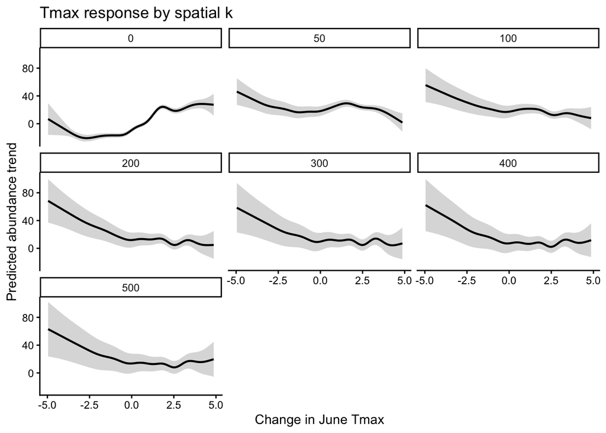

```r
curve_data %>%
  filter(focal_var == "tmax_june_delta") %>%
  ggplot(
    aes(
      x = climate_value,
      y = fit
    )
  ) +
  geom_ribbon(
    aes(
      ymin = lower,
      ymax = upper
    ),
    alpha = 0.2
  ) +
  geom_line(linewidth = 0.8) +
  facet_wrap(~ spatial_k, ncol = 3) +
  theme_classic() +
  labs(
    x = "Change in June Tmax",
    y = "Predicted abundance trend",
    title = "Tmax response by spatial k"
  )
```

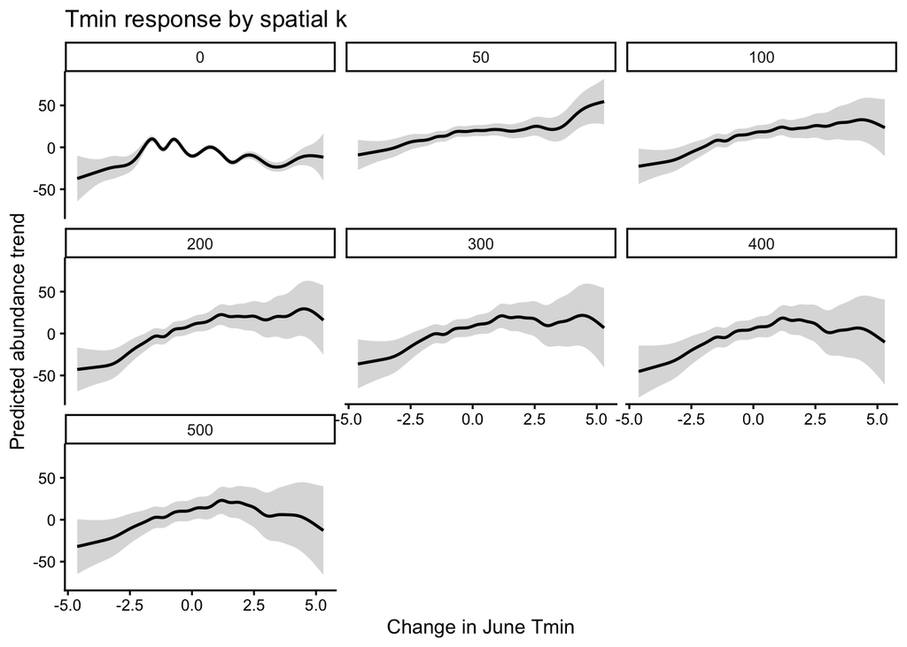

```r
curve_data %>%
  filter(focal_var == "tmin_june_delta") %>%
  ggplot(
    aes(
      x = climate_value,
      y = fit
    )
  ) +
  geom_ribbon(
    aes(
      ymin = lower,
      ymax = upper
    ),
    alpha = 0.2
  ) +
  geom_line(linewidth = 0.8) +
  facet_wrap(~ spatial_k, ncol = 3) +
  theme_classic() +
  labs(
    x = "Change in June Tmin",
    y = "Predicted abundance trend",
    title = "Tmin response by spatial k"
  )
```

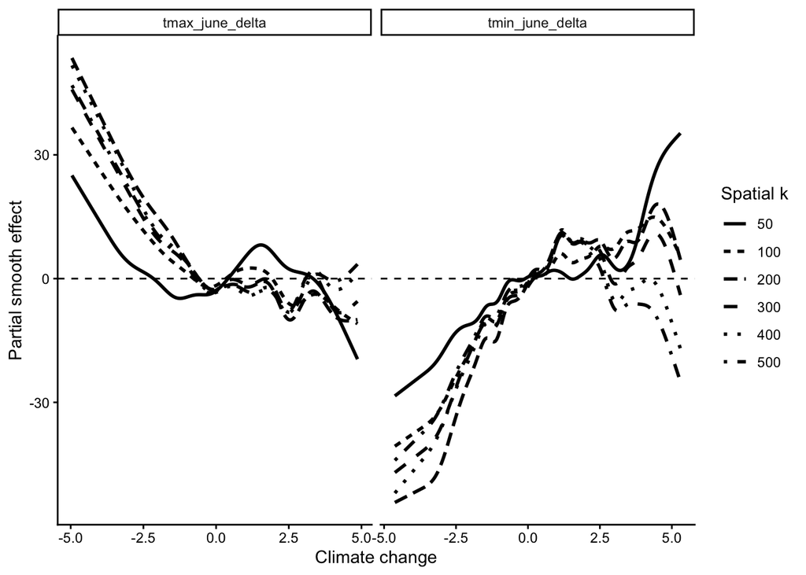

```r
get_smooth_curve <- function(mod, model_name, focal_var, data, n = 200) {

  xseq <- seq(
    min(data[[focal_var]], na.rm = TRUE),
    max(data[[focal_var]], na.rm = TRUE),
    length.out = n
  )

  newdat <- data.frame(
    tmax_june_delta = median(data$tmax_june_delta, na.rm = TRUE),
    tmin_june_delta = median(data$tmin_june_delta, na.rm = TRUE),
    x = median(data$x, na.rm = TRUE),
    y = median(data$y, na.rm = TRUE)
  )

  newdat <- newdat[rep(1, n), ]
  newdat[[focal_var]] <- xseq

  term_name <- paste0("s(", focal_var, ")")

  pred <- predict(
    mod,
    newdata = newdat,
    type = "terms",
    se.fit = TRUE
  )

  tibble(
    model = model_name,
    spatial_k = as.numeric(sub("k", "", model_name)),
    focal_var = focal_var,
    climate_value = xseq,
    fit = pred$fit[, term_name],
    se = pred$se.fit[, term_name],
    lower = fit - 1.96 * se,
    upper = fit + 1.96 * se
  )
}

smooth_curve_data <- map_dfr(
  names(gam_k_models),
  function(nm) {

    mod <- gam_k_models[[nm]]

    bind_rows(
      get_smooth_curve(
        mod, nm,
        "tmax_june_delta",
        clean.data
      ),
      get_smooth_curve(
        mod, nm,
        "tmin_june_delta",
        clean.data
      )
    )
  }
)

smooth_curve_data %>%
  ggplot(
    aes(
      x = climate_value,
      y = fit,
      linetype = factor(spatial_k),
      group = spatial_k
    )
  ) +
  geom_hline(yintercept = 0, linetype = "dashed") +
  geom_line(linewidth = 1) +
  facet_wrap(
    ~ focal_var,
    scales = "free_x"
  ) +
  theme_classic() +
  labs(
    x = "Climate change",
    y = "Partial smooth effect",
    linetype = "Spatial k"
  )
```

```r
pairwise_concurvity[["k100"]]
```

```
## $worst
##                            para s(tmax_june_delta) s(tmin_june_delta)
## para               1.000000e+00       2.033556e-26       1.122250e-25
## s(tmax_june_delta) 2.254555e-26       1.000000e+00       8.138370e-01
## s(tmin_june_delta) 1.142814e-25       8.138370e-01       1.000000e+00
## s(x,y)             5.452579e-24       9.807430e-01       9.688783e-01
##                          s(x,y)
## para               5.447360e-24
## s(tmax_june_delta) 9.807430e-01
## s(tmin_june_delta) 9.688783e-01
## s(x,y)             1.000000e+00
##
## $observed
##                            para s(tmax_june_delta) s(tmin_june_delta)
## para               1.000000e+00       3.153711e-30       4.062544e-29
## s(tmax_june_delta) 2.254555e-26       1.000000e+00       6.815020e-01
## s(tmin_june_delta) 1.142814e-25       4.381804e-01       1.000000e+00
## s(x,y)             5.452579e-24       8.460470e-01       8.928307e-01
##                          s(x,y)
## para               1.380525e-26
## s(tmax_june_delta) 2.320723e-01
## s(tmin_june_delta) 1.052216e-01
## s(x,y)             1.000000e+00
##
## $estimate
##                            para s(tmax_june_delta) s(tmin_june_delta)
## para               1.000000e+00       5.380384e-30       4.962281e-29
## s(tmax_june_delta) 2.254555e-26       1.000000e+00       7.010123e-01
## s(tmin_june_delta) 1.142814e-25       6.645304e-01       1.000000e+00
## s(x,y)             5.452579e-24       9.303284e-01       9.051641e-01
##                          s(x,y)
## para               2.184956e-26
## s(tmax_june_delta) 1.899469e-01
## s(tmin_june_delta) 1.658031e-01
## s(x,y)             1.000000e+00
```

```r
pairwise_concurvity[["k200"]]
```

```
## $worst
##                            para s(tmax_june_delta) s(tmin_june_delta)
## para               1.000000e+00       2.033556e-26       1.122250e-25
## s(tmax_june_delta) 2.254555e-26       1.000000e+00       8.138370e-01
## s(tmin_june_delta) 1.142814e-25       8.138370e-01       1.000000e+00
## s(x,y)             2.563559e-22       9.919922e-01       9.862245e-01
##                          s(x,y)
## para               2.564182e-22
## s(tmax_june_delta) 9.919922e-01
## s(tmin_june_delta) 9.862245e-01
## s(x,y)             1.000000e+00
##
## $observed
##                            para s(tmax_june_delta) s(tmin_june_delta)
## para               1.000000e+00       1.122838e-30       4.353517e-29
## s(tmax_june_delta) 2.254555e-26       1.000000e+00       6.121005e-01
## s(tmin_june_delta) 1.142814e-25       4.791807e-01       1.000000e+00
## s(x,y)             2.563559e-22       9.211725e-01       9.354832e-01
##                          s(x,y)
## para               2.883005e-26
## s(tmax_june_delta) 2.310242e-01
## s(tmin_june_delta) 9.828030e-02
## s(x,y)             1.000000e+00
##
## $estimate
##                            para s(tmax_june_delta) s(tmin_june_delta)
## para               1.000000e+00       5.380384e-30       4.962281e-29
## s(tmax_june_delta) 2.254555e-26       1.000000e+00       7.010123e-01
## s(tmin_june_delta) 1.142814e-25       6.645304e-01       1.000000e+00
## s(x,y)             2.563559e-22       9.599035e-01       9.433360e-01
##                          s(x,y)
## para               2.194903e-25
## s(tmax_june_delta) 1.879880e-01
## s(tmin_june_delta) 1.628700e-01
## s(x,y)             1.000000e+00
```

```r
cor(
  clean.data$tmax_june_delta,
  clean.data$tmin_june_delta,
  use = "complete.obs"
)
```

```
## [1] 0.8334811
```

At k = 100, the observed pairwise concurvity is roughly:

Tmax explained by Tmin: 0.68 Tmin explained by Tmax: 0.44 Tmax explained by space: 0.23 Tmin explained by space: 0.11 space explained by Tmax: 0.85 space explained by Tmin: 0.89

The spatial smooth contains a lot of structure that can be reconstructed from the temperature variables, but the fitted temperature smooths themselves are not overwhelmingly reconstructed by the spatial smooth in the observed metric.

At k = 200, the same pattern holds:

Tmax from space: ~0.23 Tmin from space: ~0.10 space from Tmax: ~0.92 space from Tmin: ~0.94

So increasing spatial complexity makes the spatial surface increasingly climate-like, but it does not greatly increase the amount of the fitted Tmax/Tmin smooths that is represented by space.

But, Tmax and Tmin are highly correlated and so cannot be interpretted as having separate effects. The Pearson r=0.83 is high and would usually warrant exclusion of one of the variables… Let’s see what happens modeling them seperataly…

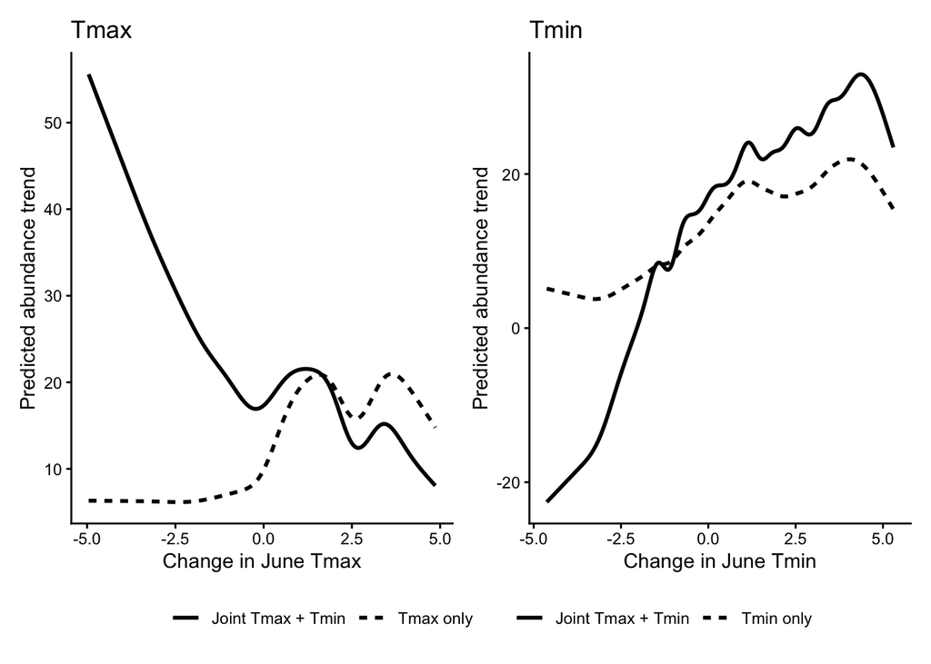

```r
gam_tmax_k100 <- gam(
  abd_trend ~
    s(tmax_june_delta, k = 15, bs = "tp") +
    s(x, y, k = 100, bs = "tp"),
  data = clean.data,
  method = "REML"
)

gam_tmin_k100 <- gam(
  abd_trend ~
    s(tmin_june_delta, k = 25, bs = "tp") +
    s(x, y, k = 100, bs = "tp"),
  data = clean.data,
  method = "REML"
)

gam_joint_k100 <- gam_k_models[["k100"]]

tmax_compare <- bind_rows(
  get_curve(
    gam_joint_k100,
    model_name = "Joint Tmax + Tmin",
    focal_var = "tmax_june_delta",
    data = clean.data
  ),
  get_curve(
    gam_tmax_k100,
    model_name = "Tmax only",
    focal_var = "tmax_june_delta",
    data = clean.data
  )
)
tmin_compare <- bind_rows(
  get_curve(
    gam_joint_k100,
    model_name = "Joint Tmax + Tmin",
    focal_var = "tmin_june_delta",
    data = clean.data
  ),
  get_curve(
    gam_tmin_k100,
    model_name = "Tmin only",
    focal_var = "tmin_june_delta",
    data = clean.data
  )
)
library(patchwork)
p_tmax <- ggplot(
  tmax_compare,
  aes(
    x = climate_value,
    y = fit,
    linetype = model,
    group = model
  )
) +
  geom_line(linewidth = 1) +
  theme_classic() +
  labs(
    x = "Change in June Tmax",
    y = "Predicted abundance trend",
    linetype = NULL,
    title = "Tmax"
  )

p_tmin <- ggplot(
  tmin_compare,
  aes(
    x = climate_value,
    y = fit,
    linetype = model,
    group = model
  )
) +
  geom_line(linewidth = 1) +
  theme_classic() +
  labs(
    x = "Change in June Tmin",
    y = "Predicted abundance trend",
    linetype = NULL,
    title = "Tmin"
  )

p_tmax + p_tmin +
  plot_layout(guides = "collect") &
  theme(legend.position = "bottom")
```

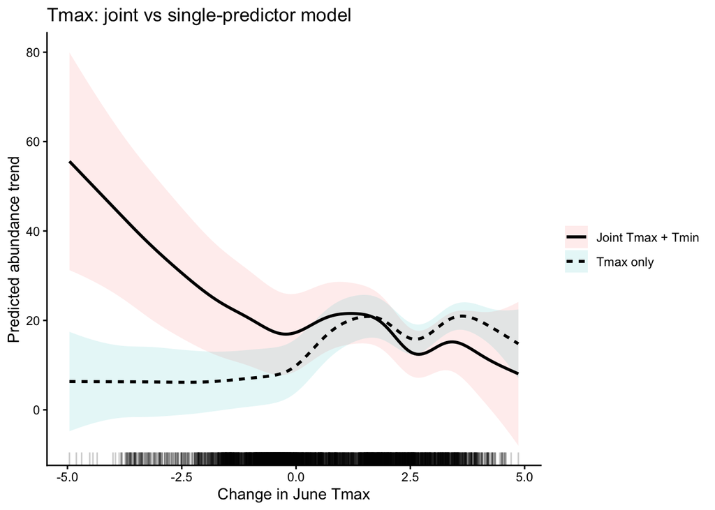

```r
ggplot(
  tmax_compare,
  aes(
    x = climate_value,
    y = fit,
    group = model,
    linetype = model
  )
) +
  geom_ribbon(
    aes(
      ymin = lower,
      ymax = upper,
      fill = model
    ),
    alpha = 0.12,
    linetype = 0
  ) +
  geom_line(linewidth = 1) +
  geom_rug(
    data = clean.data,
    aes(x = tmax_june_delta),
    inherit.aes = FALSE,
    sides = "b",
    alpha = 0.2
  ) +
  theme_classic() +
  labs(
    x = "Change in June Tmax",
    y = "Predicted abundance trend",
    linetype = NULL,
    fill = NULL,
    title = "Tmax: joint vs single-predictor model"
  )
```

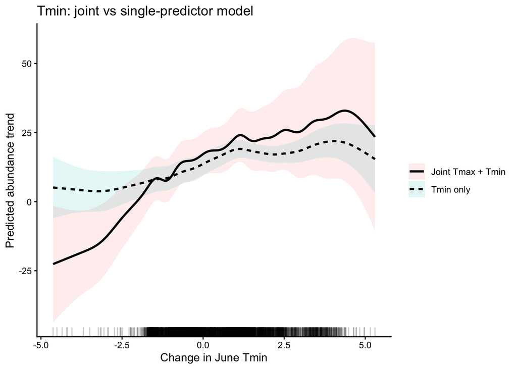

```r
ggplot(
  tmin_compare,
  aes(
    x = climate_value,
    y = fit,
    group = model,
    linetype = model
  )
) +
  geom_ribbon(
    aes(
      ymin = lower,
      ymax = upper,
      fill = model
    ),
    alpha = 0.12,
    linetype = 0
  ) +
  geom_line(linewidth = 1) +
  geom_rug(
    data = clean.data,
    aes(x = tmin_june_delta),
    inherit.aes = FALSE,
    sides = "b",
    alpha = 0.2
  ) +
  theme_classic() +
  labs(
    x = "Change in June Tmin",
    y = "Predicted abundance trend",
    linetype = NULL,
    fill = NULL,
    title = "Tmin: joint vs single-predictor model"
  )
```

# G model

```r
# modG.ppt_tmax <- gam(
#   abd_trend ~
#     s(ppt_june_delta, k = 20, bs = "tp") +
#     s(tmax_june_delta, k = 15, bs = "tp") +
#     s(x, y, k = 200, bs = "tp") +
#     s(AU, bs = "re"),
#   data = clean.data,
#   method = "REML"
# )

# saveRDS(modG.ppt_tmax, "../scratch/model_storage/modG.ppt_tmax")
modG.ppt_tmax <- readRDS("../scratch/model_storage/modG.ppt_tmax")

summary(modG.ppt_tmax)
```

```
##
## Family: gaussian
## Link function: identity
##
## Formula:
## abd_trend ~ s(ppt_june_delta, k = 20, bs = "tp") + s(tmax_june_delta,
##     k = 15, bs = "tp") + s(x, y, k = 200, bs = "tp") + s(AU,
##     bs = "re")
##
## Parametric coefficients:
##             Estimate Std. Error t value Pr(>|t|)
## (Intercept)   1.4644     0.1534   9.547   <2e-16 ***
## ---
## Signif. codes:  0 '***' 0.001 '**' 0.01 '*' 0.05 '.' 0.1 ' ' 1
##
## Approximate significance of smooth terms:
##                          edf  Ref.df      F p-value
## s(ppt_june_delta)  4.534e+00   5.896  2.049  0.0571 .
## s(tmax_june_delta) 1.190e+01  13.290  7.987  <2e-16 ***
## s(x,y)             1.771e+02 194.379 67.592  <2e-16 ***
## s(AU)              1.153e-04   2.000  0.000  0.3744
## ---
## Signif. codes:  0 '***' 0.001 '**' 0.01 '*' 0.05 '.' 0.1 ' ' 1
##
## R-sq.(adj) =  0.844   Deviance explained = 85.2%
## -REML =  15225  Scale est. = 90.518    n = 4055
```

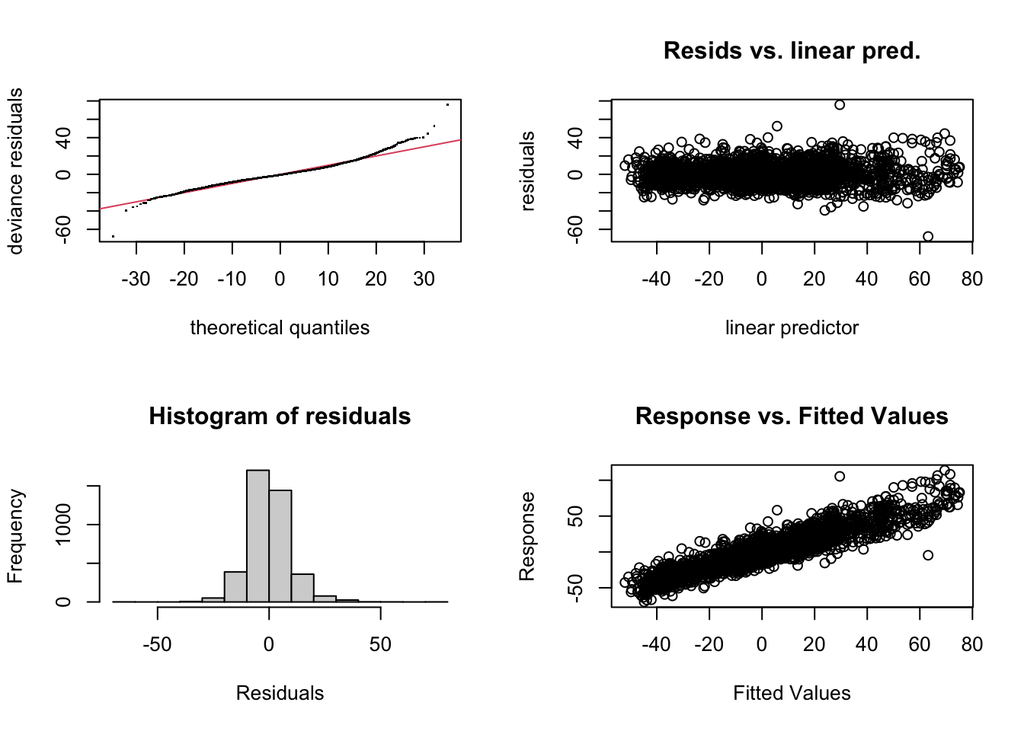

```
##
## Method: REML   Optimizer: outer newton
## full convergence after 12 iterations.
## Gradient range [-0.0002467915,9.531929e-06]
## (score 15225.13 & scale 90.51761).
## Hessian positive definite, eigenvalue range [2.511298e-05,2028.929].
## Model rank =  236 / 236
##
## Basis dimension (k) checking results. Low p-value (k-index<1) may
## indicate that k is too low, especially if edf is close to k'.
##
##                          k'      edf k-index p-value
## s(ppt_june_delta)  1.90e+01 4.53e+00    1.00    0.42
## s(tmax_june_delta) 1.40e+01 1.19e+01    1.00    0.55
## s(x,y)             1.99e+02 1.77e+02    0.63  <2e-16 ***
## s(AU)              3.00e+00 1.15e-04      NA      NA
## ---
## Signif. codes:  0 '***' 0.001 '**' 0.01 '*' 0.05 '.' 0.1 ' ' 1
```

```r
gam.check(modG.ppt_tmax)
```

```r
concurvity(modG.ppt_tmax, full = TRUE)
```

```
##          para s(ppt_june_delta) s(tmax_june_delta)    s(x,y)     s(AU)
## worst       1         0.9461128          0.9925649 0.9997584 1.0000000
## observed    1         0.8256978          0.9648144 0.6231574 0.9995172
## estimate    1         0.8879350          0.9610929 0.6307724 0.9993681
```

```r
concurvity(modG.ppt_tmax, full = FALSE)
```

```
## $worst
##                            para s(ppt_june_delta) s(tmax_june_delta)
## para               1.000000e+00      5.079225e-26       2.033556e-26
## s(ppt_june_delta)  5.528115e-26      1.000000e+00       3.097176e-01
## s(tmax_june_delta) 2.024299e-26      3.097176e-01       1.000000e+00
## s(x,y)             2.563293e-22      9.422910e-01       9.919922e-01
## s(AU)              1.000000e+00      2.436025e-01       1.835800e-01
##                          s(x,y)     s(AU)
## para               2.564182e-22 1.0000000
## s(ppt_june_delta)  9.422910e-01 0.2436025
## s(tmax_june_delta) 9.919922e-01 0.1835800
## s(x,y)             1.000000e+00 0.9997510
## s(AU)              9.997510e-01 1.0000000
##
## $observed
##                            para s(ppt_june_delta) s(tmax_june_delta)
## para               1.000000e+00      6.333258e-31       1.453172e-29
## s(ppt_june_delta)  5.528115e-26      1.000000e+00       2.104549e-01
## s(tmax_june_delta) 2.024299e-26      1.274832e-01       1.000000e+00
## s(x,y)             2.563293e-22      8.226203e-01       9.631006e-01
## s(AU)              1.000000e+00      1.302678e-03       1.549848e-01
##                          s(x,y)     s(AU)
## para               2.620834e-26 0.2421363
## s(ppt_june_delta)  1.773620e-01 0.1845893
## s(tmax_june_delta) 1.050389e-01 0.1390885
## s(x,y)             1.000000e+00 0.7573618
## s(AU)              5.238741e-01 1.0000000
##
## $estimate
##                            para s(ppt_june_delta) s(tmax_june_delta)
## para               1.000000e+00      4.367008e-29       5.380384e-30
## s(ppt_june_delta)  5.528115e-26      1.000000e+00       2.189068e-01
## s(tmax_june_delta) 2.024299e-26      1.897143e-01       1.000000e+00
## s(x,y)             2.563293e-22      8.826862e-01       9.599035e-01
## s(AU)              1.000000e+00      7.789312e-02       1.331813e-01
##                          s(x,y)      s(AU)
## para               2.194903e-25 0.45766524
## s(ppt_june_delta)  1.824223e-01 0.10564367
## s(tmax_june_delta) 1.879880e-01 0.09288107
## s(x,y)             1.000000e+00 0.54167785
## s(AU)              5.748121e-01 1.00000000
```

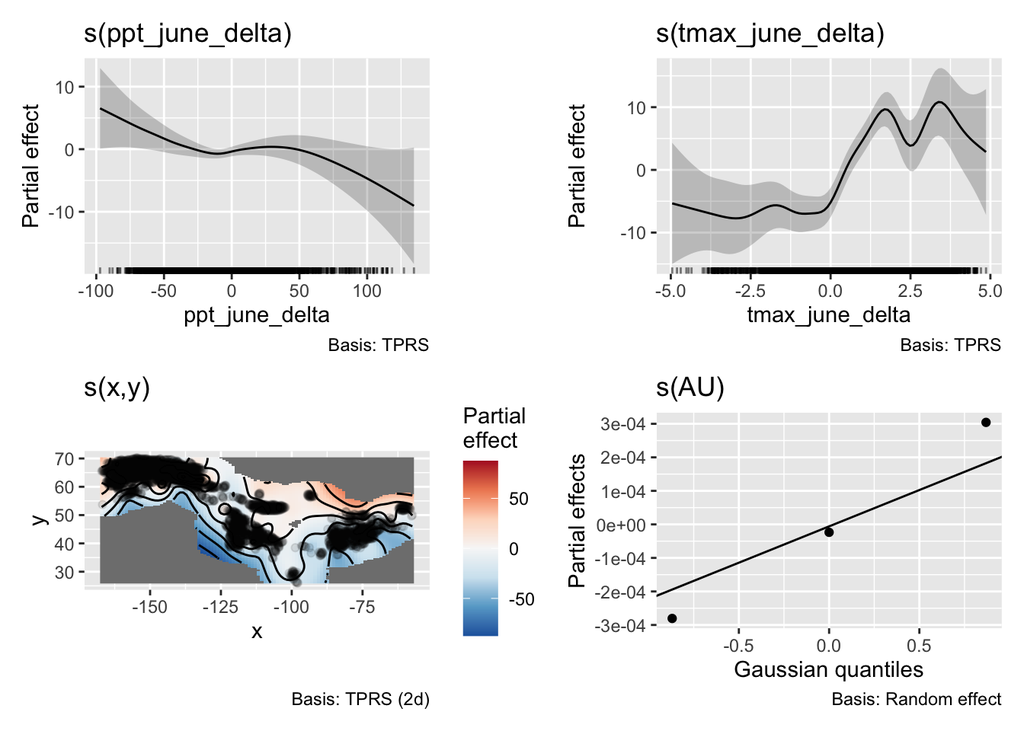

```r
gratia::draw(modG.ppt_tmax)
```

```r
# modG.ppt_tmin <- gam(
#   abd_trend ~
#     s(ppt_june_delta, k = 20, bs = "tp") +
#     s(tmin_june_delta, k = 25, bs = "tp") +
#     s(x, y, k = 200, bs = "tp") +
#     s(AU, bs = "re"),
#   data = clean.data,
#   method = "REML"
# )

# saveRDS(modG.ppt_tmin, "../scratch/model_storage/modG.ppt_tmin")
modG.ppt_tmin <- readRDS("../scratch/model_storage/modG.ppt_tmin")

summary(modG.ppt_tmin)
```

```
##
## Family: gaussian
## Link function: identity
##
## Formula:
## abd_trend ~ s(ppt_june_delta, k = 20, bs = "tp") + s(tmin_june_delta,
##     k = 25, bs = "tp") + s(x, y, k = 200, bs = "tp") + s(AU,
##     bs = "re")
##
## Parametric coefficients:
##             Estimate Std. Error t value Pr(>|t|)
## (Intercept)   1.4646     0.1495   9.796   <2e-16 ***
## ---
## Signif. codes:  0 '***' 0.001 '**' 0.01 '*' 0.05 '.' 0.1 ' ' 1
##
## Approximate significance of smooth terms:
##                          edf  Ref.df      F p-value
## s(ppt_june_delta)  4.140e+00   5.402  1.320   0.245
## s(tmin_june_delta) 1.821e+01  21.224  4.969  <2e-16 ***
## s(x,y)             1.777e+02 194.639 80.846  <2e-16 ***
## s(AU)              7.086e-06   2.000  0.000   0.439
## ---
## Signif. codes:  0 '***' 0.001 '**' 0.01 '*' 0.05 '.' 0.1 ' ' 1
##
## R-sq.(adj) =  0.845   Deviance explained = 85.2%
## -REML =  15234  Scale est. = 90.324    n = 4055
```

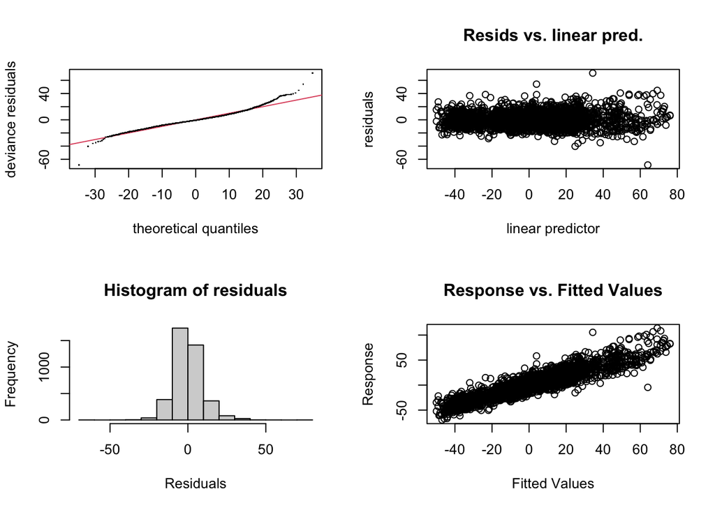

```
##
## Method: REML   Optimizer: outer newton
## full convergence after 8 iterations.
## Gradient range [-0.0002216233,2.480047e-06]
## (score 15234.22 & scale 90.32388).
## Hessian positive definite, eigenvalue range [1.944897e-06,2028.981].
## Model rank =  246 / 246
##
## Basis dimension (k) checking results. Low p-value (k-index<1) may
## indicate that k is too low, especially if edf is close to k'.
##
##                          k'      edf k-index p-value
## s(ppt_june_delta)  1.90e+01 4.14e+00    0.99   0.295
## s(tmin_june_delta) 2.40e+01 1.82e+01    0.98   0.065 .
## s(x,y)             1.99e+02 1.78e+02    0.63  <2e-16 ***
## s(AU)              3.00e+00 7.09e-06      NA      NA
## ---
## Signif. codes:  0 '***' 0.001 '**' 0.01 '*' 0.05 '.' 0.1 ' ' 1
```

```r
gam.check(modG.ppt_tmin)
```

```r
concurvity(modG.ppt_tmin, full = TRUE)
```

```
##          para s(ppt_june_delta) s(tmin_june_delta)    s(x,y)     s(AU)
## worst       1         0.9459843          0.9869612 0.9997681 1.0000000
## observed    1         0.7711578          0.9104439 0.6220625 0.9997115
## estimate    1         0.8881659          0.9446858 0.6504217 0.9993730
```

```r
concurvity(modG.ppt_tmin, full = FALSE)
```

```
## $worst
##                            para s(ppt_june_delta) s(tmin_june_delta)
## para               1.000000e+00      5.079225e-26       1.122250e-25
## s(ppt_june_delta)  5.528115e-26      1.000000e+00       3.484562e-01
## s(tmin_june_delta) 1.182985e-25      3.484562e-01       1.000000e+00
## s(x,y)             2.563134e-22      9.422910e-01       9.862245e-01
## s(AU)              1.000000e+00      2.436025e-01       1.401519e-01
##                          s(x,y)     s(AU)
## para               2.564182e-22 1.0000000
## s(ppt_june_delta)  9.422910e-01 0.2436025
## s(tmin_june_delta) 9.862245e-01 0.1401519
## s(x,y)             1.000000e+00 0.9997510
## s(AU)              9.997510e-01 1.0000000
##
## $observed
##                            para s(ppt_june_delta) s(tmin_june_delta)
## para               1.000000e+00      5.648796e-31       2.242867e-28
## s(ppt_june_delta)  5.528115e-26      1.000000e+00       5.996460e-02
## s(tmin_june_delta) 1.182985e-25      1.101556e-01       1.000000e+00
## s(x,y)             2.563134e-22      7.643477e-01       9.067763e-01
## s(AU)              1.000000e+00      2.059059e-02       3.697149e-02
##                          s(x,y)      s(AU)
## para               2.502580e-26 0.08700666
## s(ppt_june_delta)  2.040636e-01 0.17551771
## s(tmin_june_delta) 1.086544e-01 0.09137745
## s(x,y)             1.000000e+00 0.91268539
## s(AU)              5.659882e-01 1.00000000
##
## $estimate
##                            para s(ppt_june_delta) s(tmin_june_delta)
## para               1.000000e+00      4.367008e-29       4.962281e-29
## s(ppt_june_delta)  5.528115e-26      1.000000e+00       1.969235e-01
## s(tmin_june_delta) 1.182985e-25      1.864812e-01       1.000000e+00
## s(x,y)             2.563134e-22      8.826862e-01       9.433360e-01
## s(AU)              1.000000e+00      7.789312e-02       6.317787e-02
##                          s(x,y)      s(AU)
## para               2.194903e-25 0.45766524
## s(ppt_june_delta)  1.824223e-01 0.10564367
## s(tmin_june_delta) 1.628700e-01 0.06675138
## s(x,y)             1.000000e+00 0.54167785
## s(AU)              5.748121e-01 1.00000000
```

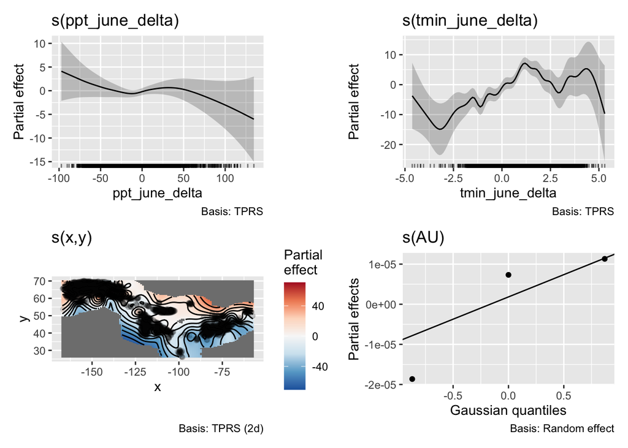

```r
gratia::draw(modG.ppt_tmin)
```

# GS Model

These test whether the environmental response differs among AUs in addition to a shared global environmental response. The bs = “sz” factor smooths represent AU-specific deviations from the global smooth.

The logic is then:

s(focal) = shared range-wide environmental response s(focal, AU, bs=“sz”) = AU-specific departures from that shared response s(AU, bs=“re”) = AU differences in overall mean trend s(x,y) = broad spatial adjustment nonfocal climate smooth = adjustment for the other retained climate dimension

## Tmax hypothesis

Does the Tmax–trend relationship vary among AUs?

```r
# modGS.tmax <- gam(
#   abd_trend ~
#     s(ppt_june_delta,  k = 20, bs = "tp") +
#     s(tmax_june_delta, k = 15, bs = "tp") +
#     s(tmax_june_delta, AU, k = 5, bs = "sz") +
#     s(x, y, k = 200, bs = "tp") +
#     s(AU, bs = "re"),
#   data = clean.data,
#   method = "REML"
# )

# saveRDS(modGS.tmax, "../scratch/model_storage/modGS.tmax")
modGS.tmax <- readRDS("../scratch/model_storage/modGS.tmax")

summary(modGS.tmax)
```

```
##
## Family: gaussian
## Link function: identity
##
## Formula:
## abd_trend ~ s(ppt_june_delta, k = 20, bs = "tp") + s(tmax_june_delta,
##     k = 15, bs = "tp") + s(tmax_june_delta, AU, k = 5, bs = "sz") +
##     s(x, y, k = 200, bs = "tp") + s(AU, bs = "re")
##
## Parametric coefficients:
##             Estimate Std. Error t value Pr(>|t|)
## (Intercept)  -19.244      4.429  -4.345 1.43e-05 ***
## ---
## Signif. codes:  0 '***' 0.001 '**' 0.01 '*' 0.05 '.' 0.1 ' ' 1
##
## Approximate significance of smooth terms:
##                              edf  Ref.df      F p-value
## s(ppt_june_delta)      5.218e+00   6.757  2.663  0.0114 *
## s(tmax_june_delta)     1.186e+01  13.225  7.335  <2e-16 ***
## s(tmax_june_delta,AU)  8.544e+00   9.019 10.047  <2e-16 ***
## s(x,y)                 1.760e+02 193.760 31.514  <2e-16 ***
## s(AU)                 -4.675e-16   3.000  0.000  <2e-16 ***
## ---
## Signif. codes:  0 '***' 0.001 '**' 0.01 '*' 0.05 '.' 0.1 ' ' 1
##
## R-sq.(adj) =  0.848   Deviance explained = 85.5%
## -REML =  15178  Scale est. = 88.365    n = 4055
```

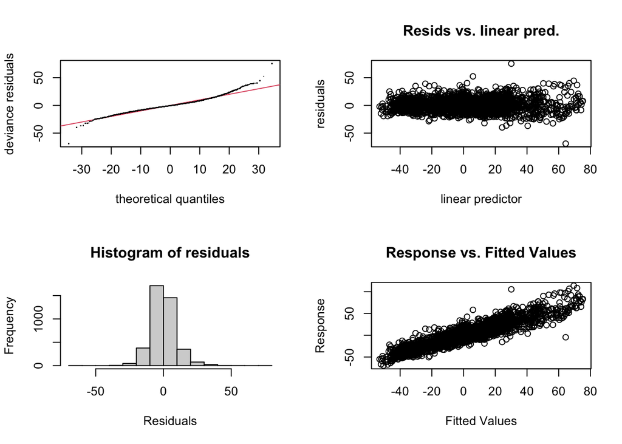

```
##
## Method: REML   Optimizer: outer newton
## full convergence after 19 iterations.
## Gradient range [-0.01475826,0.004832346]
## (score 15178.28 & scale 88.36484).
## eigenvalue range [-1.116331e-15,2026.9].
## Model rank =  246 / 246
##
## Basis dimension (k) checking results. Low p-value (k-index<1) may
## indicate that k is too low, especially if edf is close to k'.
##
##                              k'       edf k-index p-value
## s(ppt_june_delta)      1.90e+01  5.22e+00    1.00     0.4
## s(tmax_june_delta)     1.40e+01  1.19e+01    1.00     0.5
## s(tmax_june_delta,AU)  1.00e+01  8.54e+00      NA      NA
## s(x,y)                 1.99e+02  1.76e+02    0.65  <2e-16 ***
## s(AU)                  3.00e+00 -4.67e-16      NA      NA
## ---
## Signif. codes:  0 '***' 0.001 '**' 0.01 '*' 0.05 '.' 0.1 ' ' 1
```

```r
gam.check(modGS.tmax)
```

```r
concurvity(modGS.tmax, full = TRUE)
```

```
##          para s(ppt_june_delta) s(tmax_june_delta) s(tmax_june_delta,AU)
## worst       1         0.9509884          0.9999007             1.0000000
## observed    1         0.8502020          0.9907485             0.9988691
## estimate    1         0.8932437          0.9833814             0.9920577
##             s(x,y) s(AU)
## worst    0.9997678     1
## observed 0.3803508     1
## estimate 0.6462820     1
```

```r
concurvity(modGS.tmax, full = FALSE)
```

```
## $worst
##                               para s(ppt_june_delta) s(tmax_june_delta)
## para                  1.000000e+00      5.079225e-26       2.033556e-26
## s(ppt_june_delta)     5.528115e-26      1.000000e+00       3.097176e-01
## s(tmax_june_delta)    2.024299e-26      3.097176e-01       1.000000e+00
## s(tmax_june_delta,AU) 5.934502e-01      2.843356e-01       9.814763e-01
## s(x,y)                2.562403e-22      9.422910e-01       9.919922e-01
## s(AU)                 1.000000e+00      2.436025e-01       1.835800e-01
##                       s(tmax_june_delta,AU)       s(x,y)     s(AU)
## para                              0.5934502 2.564182e-22 1.0000000
## s(ppt_june_delta)                 0.2843356 9.422910e-01 0.2436025
## s(tmax_june_delta)                0.9814763 9.919922e-01 0.1835800
## s(tmax_june_delta,AU)             1.0000000 9.991354e-01 1.0000000
## s(x,y)                            0.9991354 1.000000e+00 0.9997510
## s(AU)                             1.0000000 9.997510e-01 1.0000000
##
## $observed
##                               para s(ppt_june_delta) s(tmax_june_delta)
## para                  1.000000e+00      2.871761e-31       9.507423e-30
## s(ppt_june_delta)     5.528115e-26      1.000000e+00       2.581314e-01
## s(tmax_june_delta)    2.024299e-26      1.485540e-01       1.000000e+00
## s(tmax_june_delta,AU) 5.934502e-01      1.974309e-01       8.078263e-01
## s(x,y)                2.562403e-22      8.423758e-01       9.715273e-01
## s(AU)                 1.000000e+00      6.367137e-03       1.026920e-01
##                       s(tmax_june_delta,AU)       s(x,y)      s(AU)
## para                              0.3530952 3.326267e-26 0.58315704
## s(ppt_june_delta)                 0.1637311 7.973485e-02 0.09069486
## s(tmax_june_delta)                0.4881533 9.987671e-02 0.07356397
## s(tmax_june_delta,AU)             1.0000000 2.657779e-01 0.93995345
## s(x,y)                            0.6427051 1.000000e+00 0.41623011
## s(AU)                             0.7369013 1.705627e-01 1.00000000
##
## $estimate
##                               para s(ppt_june_delta) s(tmax_june_delta)
## para                  1.000000e+00      4.367008e-29       5.380384e-30
## s(ppt_june_delta)     5.528115e-26      1.000000e+00       2.189068e-01
## s(tmax_june_delta)    2.024299e-26      1.897143e-01       1.000000e+00
## s(tmax_june_delta,AU) 5.934502e-01      1.622740e-01       7.560031e-01
## s(x,y)                2.562403e-22      8.826862e-01       9.599035e-01
## s(AU)                 1.000000e+00      7.789312e-02       1.331813e-01
##                       s(tmax_june_delta,AU)       s(x,y)      s(AU)
## para                              0.1317251 2.194903e-25 0.45766524
## s(ppt_june_delta)                 0.1633455 1.824223e-01 0.10564367
## s(tmax_june_delta)                0.3806683 1.879880e-01 0.09288107
## s(tmax_june_delta,AU)             1.0000000 5.144057e-01 0.86448339
## s(x,y)                            0.8536319 1.000000e+00 0.54167785
## s(AU)                             0.5006038 5.748121e-01 1.00000000
```

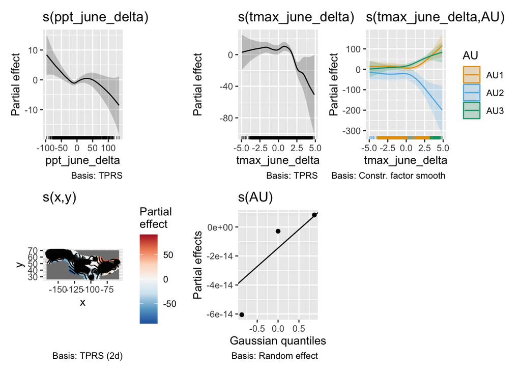

```r
gratia::draw(modGS.tmax)
```

## Tmin hypothesis

Does the Tmin–trend relationship vary among AUs?

```r
# modGS.tmin <- gam(
#   abd_trend ~
#     s(ppt_june_delta,  k = 20, bs = "tp") +
#     s(tmin_june_delta, k = 25, bs = "tp") +
#     s(tmin_june_delta, AU, k = 5, bs = "sz") +
#     s(x, y, k = 200, bs = "tp") +
#     s(AU, bs = "re"),
#   data = clean.data,
#   method = "REML"
# )

# saveRDS(modGS.tmin, "../scratch/model_storage/modGS.tmin")
modGS.tmin <- readRDS("../scratch/model_storage/modGS.tmin")

summary(modGS.tmin)
```

```
##
## Family: gaussian
## Link function: identity
##
## Formula:
## abd_trend ~ s(ppt_june_delta, k = 20, bs = "tp") + s(tmin_june_delta,
##     k = 25, bs = "tp") + s(tmin_june_delta, AU, k = 5, bs = "sz") +
##     s(x, y, k = 200, bs = "tp") + s(AU, bs = "re")
##
## Parametric coefficients:
##             Estimate Std. Error t value Pr(>|t|)
## (Intercept)   -5.283      3.349  -1.577    0.115
##
## Approximate significance of smooth terms:
##                             edf  Ref.df      F p-value
## s(ppt_june_delta)     4.131e+00   5.395  1.436   0.201
## s(tmin_june_delta)    1.869e+01  21.625  5.313  <2e-16 ***
## s(tmin_june_delta,AU) 6.803e+00   6.955 14.283  <2e-16 ***
## s(x,y)                1.765e+02 194.026 28.654  <2e-16 ***
## s(AU)                 1.090e-15   3.000  0.000   0.365
## ---
## Signif. codes:  0 '***' 0.001 '**' 0.01 '*' 0.05 '.' 0.1 ' ' 1
##
## R-sq.(adj) =  0.848   Deviance explained = 85.6%
## -REML =  15184  Scale est. = 88.173    n = 4055
```

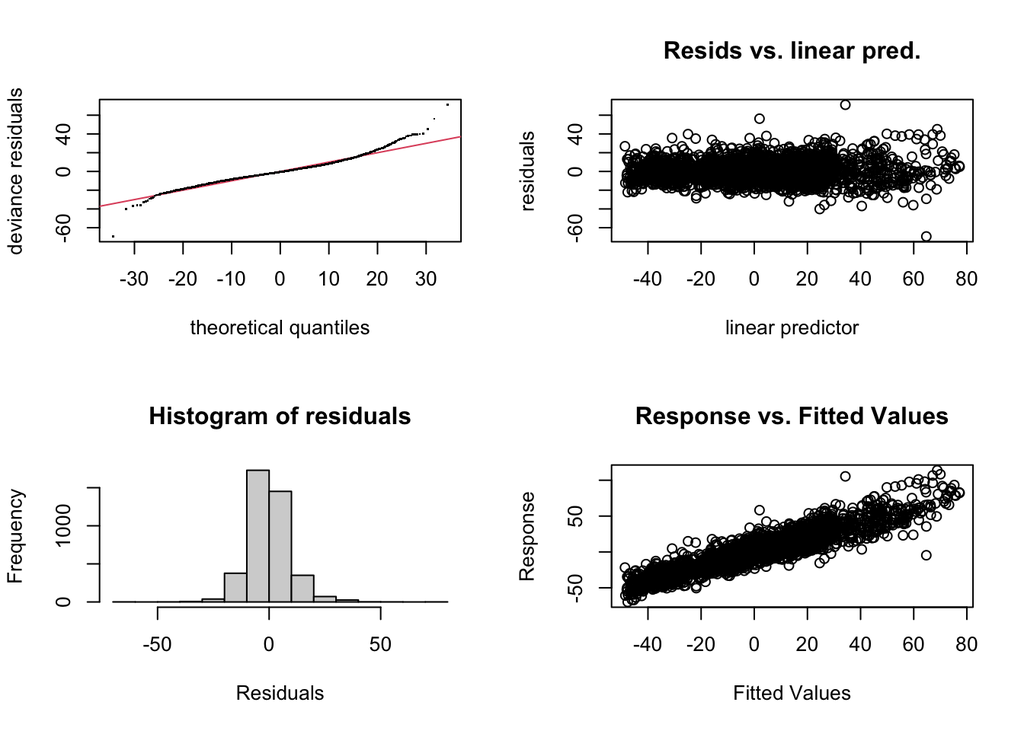

```
##
## Method: REML   Optimizer: outer newton
## full convergence after 14 iterations.
## Gradient range [-0.0007384568,0.001279515]
## (score 15183.63 & scale 88.17348).
## eigenvalue range [-7.42289e-05,2026.928].
## Model rank =  256 / 256
##
## Basis dimension (k) checking results. Low p-value (k-index<1) may
## indicate that k is too low, especially if edf is close to k'.
##
##                             k'      edf k-index p-value
## s(ppt_june_delta)     1.90e+01 4.13e+00    1.00    0.45
## s(tmin_june_delta)    2.40e+01 1.87e+01    0.98    0.12
## s(tmin_june_delta,AU) 1.00e+01 6.80e+00      NA      NA
## s(x,y)                1.99e+02 1.77e+02    0.64  <2e-16 ***
## s(AU)                 3.00e+00 1.09e-15      NA      NA
## ---
## Signif. codes:  0 '***' 0.001 '**' 0.01 '*' 0.05 '.' 0.1 ' ' 1
```

```r
gam.check(modGS.tmin)
```

```r
concurvity(modGS.tmin, full = TRUE)
```

```
##          para s(ppt_june_delta) s(tmin_june_delta) s(tmin_june_delta,AU)
## worst       1         0.9470520          0.9985716             1.0000000
## observed    1         0.7780990          0.9739122             0.9948495
## estimate    1         0.8907381          0.9719690             0.9890938
##             s(x,y) s(AU)
## worst    0.9997914     1
## observed 0.3923437     1
## estimate 0.6749413     1
```

```r
concurvity(modGS.tmin, full = FALSE)
```

```
## $worst
##                               para s(ppt_june_delta) s(tmin_june_delta)
## para                  1.000000e+00      5.079225e-26       1.122250e-25
## s(ppt_june_delta)     5.528115e-26      1.000000e+00       3.484562e-01
## s(tmin_june_delta)    1.182985e-25      3.484562e-01       1.000000e+00
## s(tmin_june_delta,AU) 3.783173e-01      3.484668e-01       9.517473e-01
## s(x,y)                2.562773e-22      9.422910e-01       9.862245e-01
## s(AU)                 1.000000e+00      2.436025e-01       1.401519e-01
##                       s(tmin_june_delta,AU)       s(x,y)     s(AU)
## para                              0.3783173 2.564182e-22 1.0000000
## s(ppt_june_delta)                 0.3484668 9.422910e-01 0.2436025
## s(tmin_june_delta)                0.9517473 9.862245e-01 0.1401519
## s(tmin_june_delta,AU)             1.0000000 9.994075e-01 1.0000000
## s(x,y)                            0.9994075 1.000000e+00 0.9997510
## s(AU)                             1.0000000 9.997510e-01 1.0000000
##
## $observed
##                               para s(ppt_june_delta) s(tmin_june_delta)
## para                  1.000000e+00      1.065502e-30       7.796639e-29
## s(ppt_june_delta)     5.528115e-26      1.000000e+00       2.466998e-01
## s(tmin_june_delta)    1.182985e-25      1.059170e-01       1.000000e+00
## s(tmin_june_delta,AU) 3.783173e-01      1.319660e-01       7.963245e-01
## s(x,y)                2.562773e-22      7.631833e-01       9.392019e-01
## s(AU)                 1.000000e+00      2.688909e-02       4.434963e-02
##                       s(tmin_june_delta,AU)       s(x,y)      s(AU)
## para                              0.1620577 1.588110e-26 0.01821939
## s(ppt_june_delta)                 0.1855053 9.255335e-02 0.13386492
## s(tmin_june_delta)                0.1969304 1.659244e-01 0.11563495
## s(tmin_june_delta,AU)             1.0000000 2.459655e-01 0.83127110
## s(x,y)                            0.8237937 1.000000e+00 0.97973536
## s(AU)                             0.7420699 9.353032e-02 1.00000000
##
## $estimate
##                               para s(ppt_june_delta) s(tmin_june_delta)
## para                  1.000000e+00      4.367008e-29       4.962281e-29
## s(ppt_june_delta)     5.528115e-26      1.000000e+00       1.969235e-01
## s(tmin_june_delta)    1.182985e-25      1.864812e-01       1.000000e+00
## s(tmin_june_delta,AU) 3.783173e-01      2.044590e-01       7.162666e-01
## s(x,y)                2.562773e-22      8.826862e-01       9.433360e-01
## s(AU)                 1.000000e+00      7.789312e-02       6.317787e-02
##                       s(tmin_june_delta,AU)       s(x,y)      s(AU)
## para                              0.1291079 2.194903e-25 0.45766524
## s(ppt_june_delta)                 0.1887639 1.824223e-01 0.10564367
## s(tmin_june_delta)                0.4037244 1.628700e-01 0.06675138
## s(tmin_june_delta,AU)             1.0000000 5.067124e-01 0.79277242
## s(x,y)                            0.8511958 1.000000e+00 0.54167785
## s(AU)                             0.4497391 5.748121e-01 1.00000000
```

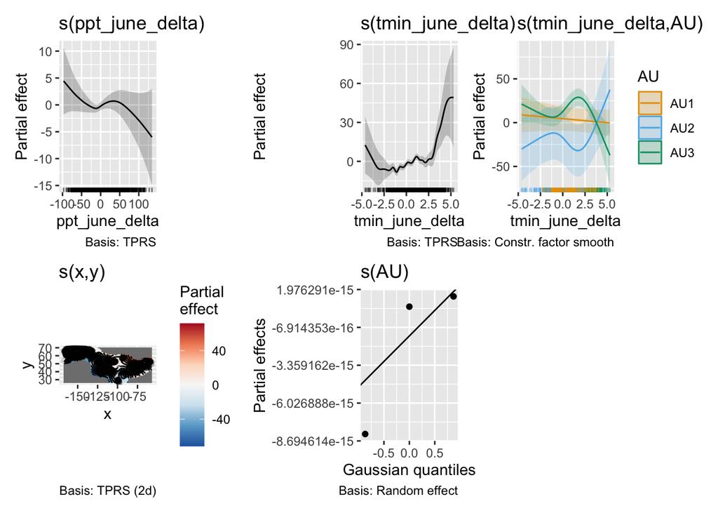

```r
gratia::draw(modGS.tmin)
```

## PPT

```r
# modGS.ppt_tmax <- gam(
#   abd_trend ~
#     s(ppt_june_delta, k = 20, bs = "tp") +
#     s(ppt_june_delta, AU, k = 5, bs = "sz") +
#     s(tmax_june_delta, k = 15, bs = "tp") +
#     s(AU, bs = "re") +
#     s(x, y, k = 200, bs = "tp"),
#   data = clean.data,
#   method = "REML"
# )

# saveRDS(modGS.ppt_tmax, "../scratch/model_storage/modGS.ppt_tmax")
modGS.ppt_tmax <- readRDS("../scratch/model_storage/modGS.ppt_tmax")

summary(modGS.ppt_tmax)
```

```
##
## Family: gaussian
## Link function: identity
##
## Formula:
## abd_trend ~ s(ppt_june_delta, k = 20, bs = "tp") + s(ppt_june_delta,
##     AU, k = 5, bs = "sz") + s(tmax_june_delta, k = 15, bs = "tp") +
##     s(AU, bs = "re") + s(x, y, k = 200, bs = "tp")
##
## Parametric coefficients:
##             Estimate Std. Error t value Pr(>|t|)
## (Intercept)   -5.402      3.228  -1.673   0.0943 .
## ---
## Signif. codes:  0 '***' 0.001 '**' 0.01 '*' 0.05 '.' 0.1 ' ' 1
##
## Approximate significance of smooth terms:
##                             edf  Ref.df      F  p-value
## s(ppt_june_delta)     1.035e+00   1.063  2.895   0.0839 .
## s(ppt_june_delta,AU)  8.795e+00   9.572  7.637  < 2e-16 ***
## s(tmax_june_delta)    1.224e+01  13.478  9.264  < 2e-16 ***
## s(AU)                -6.863e-16   3.000  0.000 1.04e-06 ***
## s(x,y)                1.767e+02 194.166 34.950  < 2e-16 ***
## ---
## Signif. codes:  0 '***' 0.001 '**' 0.01 '*' 0.05 '.' 0.1 ' ' 1
##
## R-sq.(adj) =  0.847   Deviance explained = 85.4%
## -REML =  15190  Scale est. = 88.985    n = 4055
```

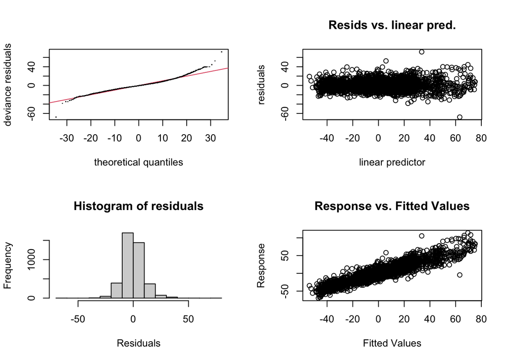

```
##
## Method: REML   Optimizer: outer newton
## full convergence after 15 iterations.
## Gradient range [-0.005642808,0.00951771]
## (score 15190.3 & scale 88.9854).
## Hessian positive definite, eigenvalue range [1.80286e-15,2026.91].
## Model rank =  246 / 246
##
## Basis dimension (k) checking results. Low p-value (k-index<1) may
## indicate that k is too low, especially if edf is close to k'.
##
##                             k'       edf k-index p-value
## s(ppt_june_delta)     1.90e+01  1.03e+00    1.00     0.4
## s(ppt_june_delta,AU)  1.00e+01  8.79e+00      NA      NA
## s(tmax_june_delta)    1.40e+01  1.22e+01    1.00     0.6
## s(AU)                 3.00e+00 -6.86e-16      NA      NA
## s(x,y)                1.99e+02  1.77e+02    0.64  <2e-16 ***
## ---
## Signif. codes:  0 '***' 0.001 '**' 0.01 '*' 0.05 '.' 0.1 ' ' 1
```

```r
gam.check(modGS.ppt_tmax)
```

```r
concurvity(modGS.ppt_tmax, full = TRUE)
```

```
##          para s(ppt_june_delta) s(ppt_june_delta,AU) s(tmax_june_delta) s(AU)
## worst       1         0.9755171            1.0000000          0.9928010     1
## observed    1         0.9570707            0.9968341          0.9539497     1
## estimate    1         0.9404403            0.9610662          0.9618724     1
##             s(x,y)
## worst    0.9997639
## observed 0.3902414
## estimate 0.6494228
```

```r
concurvity(modGS.ppt_tmax, full = FALSE)
```

```
## $worst
##                              para s(ppt_june_delta) s(ppt_june_delta,AU)
## para                 1.000000e+00      5.079225e-26            0.4662096
## s(ppt_june_delta)    5.528115e-26      1.000000e+00            0.9333741
## s(ppt_june_delta,AU) 4.662096e-01      9.333741e-01            1.0000000
## s(tmax_june_delta)   2.197207e-26      3.097176e-01            0.3243950
## s(AU)                1.000000e+00      2.436025e-01            1.0000000
## s(x,y)               2.563237e-22      9.422910e-01            0.9988824
##                      s(tmax_june_delta)     s(AU)       s(x,y)
## para                       2.033556e-26 1.0000000 2.564182e-22
## s(ppt_june_delta)          3.097176e-01 0.2436025 9.422910e-01
## s(ppt_june_delta,AU)       3.243950e-01 1.0000000 9.988824e-01
## s(tmax_june_delta)         1.000000e+00 0.1835800 9.919922e-01
## s(AU)                      1.835800e-01 1.0000000 9.997510e-01
## s(x,y)                     9.919922e-01 0.9997510 1.000000e+00
##
## $observed
##                              para s(ppt_june_delta) s(ppt_june_delta,AU)
## para                 1.000000e+00      1.751208e-32            0.1650999
## s(ppt_june_delta)    5.528115e-26      1.000000e+00            0.1538964
## s(ppt_june_delta,AU) 4.662096e-01      6.159402e-01            1.0000000
## s(tmax_june_delta)   2.197207e-26      2.486042e-01            0.1662189
## s(AU)                1.000000e+00      1.148551e-01            0.9673762
## s(x,y)               2.563237e-22      9.350759e-01            0.8302682
##                      s(tmax_june_delta)      s(AU)       s(x,y)
## para                       2.693396e-29 0.38123531 4.428633e-26
## s(ppt_june_delta)          1.913280e-01 0.09707183 4.929620e-02
## s(ppt_june_delta,AU)       2.008807e-01 0.96739500 2.593638e-01
## s(tmax_june_delta)         1.000000e+00 0.09980225 6.690088e-02
## s(AU)                      1.468387e-01 1.00000000 1.688183e-01
## s(x,y)                     9.503390e-01 0.61748100 1.000000e+00
##
## $estimate
##                              para s(ppt_june_delta) s(ppt_june_delta,AU)
## para                 1.000000e+00      4.367008e-29            0.1368944
## s(ppt_june_delta)    5.528115e-26      1.000000e+00            0.2483809
## s(ppt_june_delta,AU) 4.662096e-01      6.868017e-01            1.0000000
## s(tmax_june_delta)   2.197207e-26      1.897143e-01            0.1401942
## s(AU)                1.000000e+00      7.789312e-02            0.4549401
## s(x,y)               2.563237e-22      8.826862e-01            0.8153347
##                      s(tmax_june_delta)      s(AU)       s(x,y)
## para                       5.380384e-30 0.45766524 2.194903e-25
## s(ppt_june_delta)          2.189068e-01 0.10564367 1.824223e-01
## s(ppt_june_delta,AU)       2.349795e-01 0.82206987 5.105647e-01
## s(tmax_june_delta)         1.000000e+00 0.09288107 1.879880e-01
## s(AU)                      1.331813e-01 1.00000000 5.748121e-01
## s(x,y)                     9.599035e-01 0.54167785 1.000000e+00
```

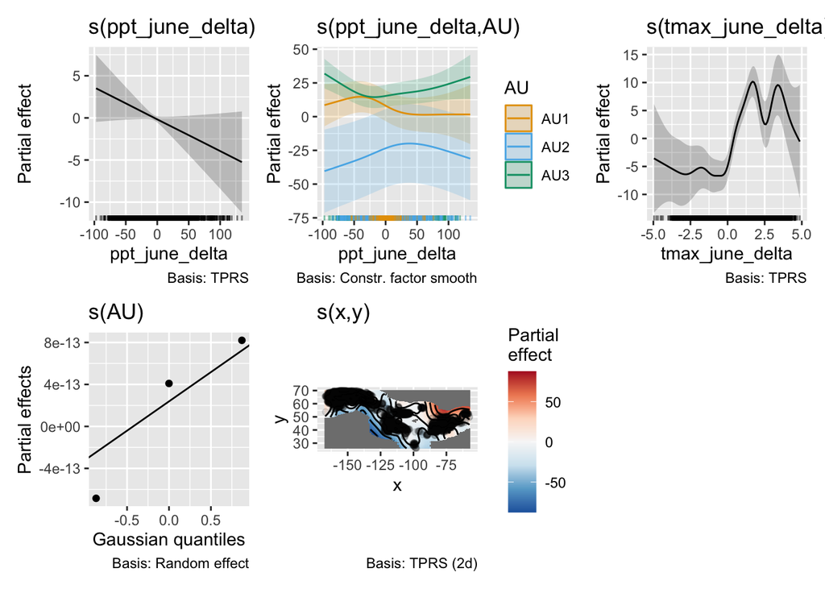

```r
gratia::draw(modGS.ppt_tmax)
```

```r
# modGS.ppt_tmin <- gam(
#   abd_trend ~
#     s(ppt_june_delta, k = 20, bs = "tp") +
#     s(ppt_june_delta, AU, k = 5, bs = "sz") +
#     s(tmin_june_delta, k = 25, bs = "tp") +
#     s(AU, bs = "re") +
#     s(x, y, k = 200, bs = "tp"),
#   data = clean.data,
#   method = "REML"
# )

# saveRDS(modGS.ppt_tmin, "../scratch/model_storage/modGS.ppt_tmin")
modGS.ppt_tmin <- readRDS("../scratch/model_storage/modGS.ppt_tmin")

summary(modGS.ppt_tmin)
```

```
##
## Family: gaussian
## Link function: identity
##
## Formula:
## abd_trend ~ s(ppt_june_delta, k = 20, bs = "tp") + s(ppt_june_delta,
##     AU, k = 5, bs = "sz") + s(tmin_june_delta, k = 25, bs = "tp") +
##     s(AU, bs = "re") + s(x, y, k = 200, bs = "tp")
##
## Parametric coefficients:
##             Estimate Std. Error t value Pr(>|t|)
## (Intercept)   -4.865      3.279  -1.484    0.138
##
## Approximate significance of smooth terms:
##                            edf  Ref.df      F p-value
## s(ppt_june_delta)    1.005e+00   1.010  0.434  0.5108
## s(ppt_june_delta,AU) 8.605e+00   9.455  5.466  <2e-16 ***
## s(tmin_june_delta)   1.796e+01  21.019  4.845  <2e-16 ***
## s(AU)                1.557e-16   3.000  0.000  0.0189 *
## s(x,y)               1.770e+02 194.274 40.497  <2e-16 ***
## ---
## Signif. codes:  0 '***' 0.001 '**' 0.01 '*' 0.05 '.' 0.1 ' ' 1
##
## R-sq.(adj) =  0.846   Deviance explained = 85.4%
## -REML =  15208  Scale est. = 89.351    n = 4055
```

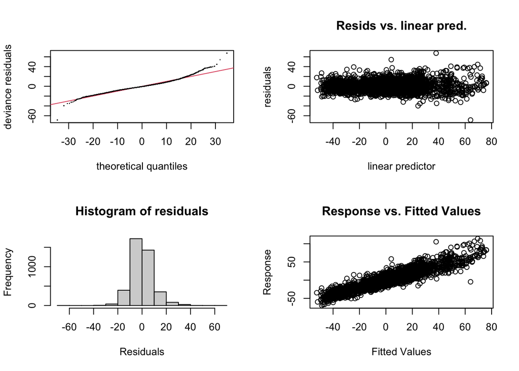

```
##
## Method: REML   Optimizer: outer newton
## full convergence after 13 iterations.
## Gradient range [-0.01176705,0.005914497]
## (score 15207.98 & scale 89.35099).
## Hessian positive definite, eigenvalue range [1.319872e-15,2026.965].
## Model rank =  256 / 256
##
## Basis dimension (k) checking results. Low p-value (k-index<1) may
## indicate that k is too low, especially if edf is close to k'.
##
##                            k'      edf k-index p-value
## s(ppt_june_delta)    1.90e+01 1.01e+00    0.99    0.26
## s(ppt_june_delta,AU) 1.00e+01 8.60e+00      NA      NA
## s(tmin_june_delta)   2.40e+01 1.80e+01    0.98    0.08 .
## s(AU)                3.00e+00 1.56e-16      NA      NA
## s(x,y)               1.99e+02 1.77e+02    0.64  <2e-16 ***
## ---
## Signif. codes:  0 '***' 0.001 '**' 0.01 '*' 0.05 '.' 0.1 ' ' 1
```

```r
gam.check(modGS.ppt_tmin)
```

```r
concurvity(modGS.ppt_tmin, full = TRUE)
```

```
##          para s(ppt_june_delta) s(ppt_june_delta,AU) s(tmin_june_delta) s(AU)
## worst       1         0.9752270            1.0000000          0.9872443     1
## observed    1         0.9558723            0.9979598          0.9040193     1
## estimate    1         0.9398944            0.9615861          0.9461326     1
##             s(x,y)
## worst    0.9997729
## observed 0.3931289
## estimate 0.6699654
```

```r
concurvity(modGS.ppt_tmin, full = FALSE)
```

```
## $worst
##                              para s(ppt_june_delta) s(ppt_june_delta,AU)
## para                 1.000000e+00      5.079225e-26            0.4662096
## s(ppt_june_delta)    5.528115e-26      1.000000e+00            0.9333741
## s(ppt_june_delta,AU) 4.662096e-01      9.333741e-01            1.0000000
## s(tmin_june_delta)   1.166995e-25      3.484562e-01            0.3579049
## s(AU)                1.000000e+00      2.436025e-01            1.0000000
## s(x,y)               2.563750e-22      9.422910e-01            0.9988824
##                      s(tmin_june_delta)     s(AU)       s(x,y)
## para                       1.122250e-25 1.0000000 2.564182e-22
## s(ppt_june_delta)          3.484562e-01 0.2436025 9.422910e-01
## s(ppt_june_delta,AU)       3.579049e-01 1.0000000 9.988824e-01
## s(tmin_june_delta)         1.000000e+00 0.1401519 9.862245e-01
## s(AU)                      1.401519e-01 1.0000000 9.997510e-01
## s(x,y)                     9.862245e-01 0.9997510 1.000000e+00
##
## $observed
##                              para s(ppt_june_delta) s(ppt_june_delta,AU)
## para                 1.000000e+00      1.880352e-32            0.1369182
## s(ppt_june_delta)    5.528115e-26      1.000000e+00            0.1616683
## s(ppt_june_delta,AU) 4.662096e-01      6.156408e-01            1.0000000
## s(tmin_june_delta)   1.166995e-25      2.128417e-01            0.1071330
## s(AU)                1.000000e+00      1.151496e-01            0.9801200
## s(x,y)               2.563750e-22      9.349688e-01            0.8599248
##                      s(tmin_june_delta)      s(AU)       s(x,y)
## para                       1.804710e-28 0.61575649 4.053513e-26
## s(ppt_june_delta)          5.097422e-02 0.06963090 5.860231e-02
## s(ppt_june_delta,AU)       9.501549e-02 0.88988573 2.967218e-01
## s(tmin_june_delta)         1.000000e+00 0.05171362 6.734706e-02
## s(AU)                      3.673920e-02 1.00000000 2.430241e-01
## s(x,y)                     8.988432e-01 0.38350420 1.000000e+00
##
## $estimate
##                              para s(ppt_june_delta) s(ppt_june_delta,AU)
## para                 1.000000e+00      4.367008e-29            0.1368944
## s(ppt_june_delta)    5.528115e-26      1.000000e+00            0.2483809
## s(ppt_june_delta,AU) 4.662096e-01      6.868017e-01            1.0000000
## s(tmin_june_delta)   1.166995e-25      1.864812e-01            0.1657646
## s(AU)                1.000000e+00      7.789312e-02            0.4549401
## s(x,y)               2.563750e-22      8.826862e-01            0.8153347
##                      s(tmin_june_delta)      s(AU)       s(x,y)
## para                       4.962281e-29 0.45766524 2.194903e-25
## s(ppt_june_delta)          1.969235e-01 0.10564367 1.824223e-01
## s(ppt_june_delta,AU)       2.578205e-01 0.82206987 5.105647e-01
## s(tmin_june_delta)         1.000000e+00 0.06675138 1.628700e-01
## s(AU)                      6.317787e-02 1.00000000 5.748121e-01
## s(x,y)                     9.433360e-01 0.54167785 1.000000e+00
```

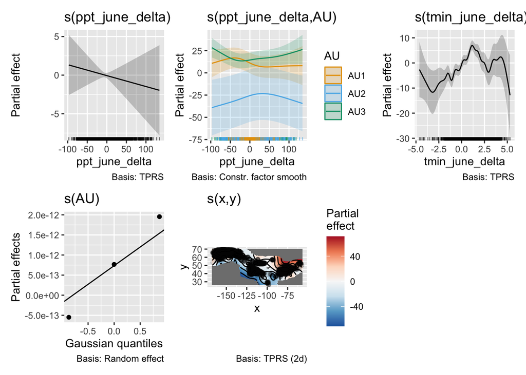

```r
gratia::draw(modGS.ppt_tmin)
```

# S Model

These remove the global smooth for the focal environmental variable and estimate only AU-specific response curves.

## Tmax hypothesis

Can the Tmax response be represented entirely by AU-specific smooths, without a shared global Tmax response?

```r
# modS.tmax <- gam(
#   abd_trend ~
#     s(ppt_june_delta, k = 20, bs = "tp") +
#     s(tmax_june_delta, AU, k = 5, bs = "fs", m = 2) +
#     s(x, y, k = 200, bs = "tp"),
#   data = clean.data,
#   method = "REML"
# )

# saveRDS(modS.tmax, "../scratch/model_storage/modS.tmax")
modS.tmax <- readRDS("../scratch/model_storage/modS.tmax")

summary(modS.tmax)
```

```
##
## Family: gaussian
## Link function: identity
##
## Formula:
## abd_trend ~ s(ppt_june_delta, k = 20, bs = "tp") + s(tmax_june_delta,
##     AU, k = 5, bs = "fs", m = 2) + s(x, y, k = 200, bs = "tp")
##
## Parametric coefficients:
##             Estimate Std. Error t value Pr(>|t|)
## (Intercept)    1.064      1.123   0.948    0.343
##
## Approximate significance of smooth terms:
##                           edf Ref.df      F p-value
## s(ppt_june_delta)       6.142   7.89  2.354  0.0204 *
## s(tmax_june_delta,AU)   9.756  14.00  7.107  <2e-16 ***
## s(x,y)                175.204 193.50 37.048  <2e-16 ***
## ---
## Signif. codes:  0 '***' 0.001 '**' 0.01 '*' 0.05 '.' 0.1 ' ' 1
##
## R-sq.(adj) =  0.844   Deviance explained = 85.1%
## -REML =  15228  Scale est. = 90.833    n = 4055
```

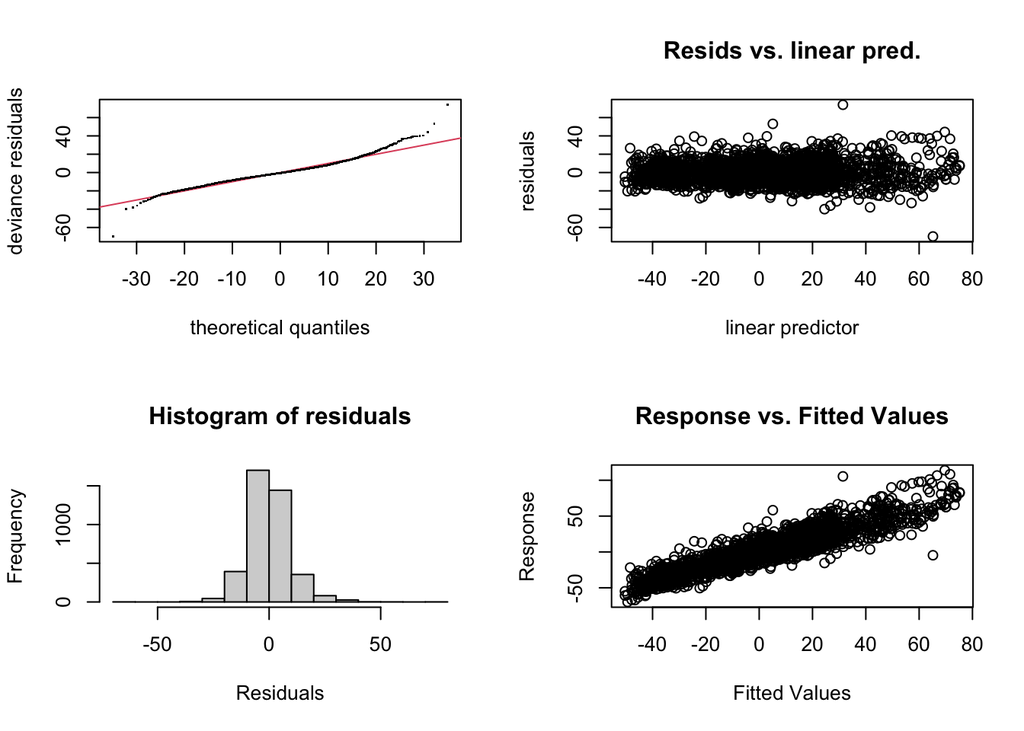

```
##
## Method: REML   Optimizer: outer newton
## full convergence after 10 iterations.
## Gradient range [-0.0001715551,0.001146857]
## (score 15227.91 & scale 90.83288).
## eigenvalue range [-0.001187303,2029.336].
## Model rank =  234 / 234
##
## Basis dimension (k) checking results. Low p-value (k-index<1) may
## indicate that k is too low, especially if edf is close to k'.
##
##                           k'    edf k-index p-value
## s(ppt_june_delta)      19.00   6.14    0.99    0.30
## s(tmax_june_delta,AU)  15.00   9.76    1.00    0.39
## s(x,y)                199.00 175.20    0.63  <2e-16 ***
## ---
## Signif. codes:  0 '***' 0.001 '**' 0.01 '*' 0.05 '.' 0.1 ' ' 1
```

```r
gam.check(modS.tmax)
```

```r
concurvity(modS.tmax, full = TRUE)
```

```
##          para s(ppt_june_delta) s(tmax_june_delta,AU)    s(x,y)
## worst       1         0.9473789             1.0000000 0.9997650
## observed    1         0.7877501             0.9855728 0.7631599
## estimate    1         0.8886329             0.9491231 0.6367648
```

```r
concurvity(modS.tmax, full = FALSE)
```

```
## $worst
##                               para s(ppt_june_delta) s(tmax_june_delta,AU)
## para                  1.000000e+00      5.079225e-26             1.0000000
## s(ppt_june_delta)     5.528115e-26      1.000000e+00             0.3437584
## s(tmax_june_delta,AU) 1.000000e+00      3.437584e-01             1.0000000
## s(x,y)                2.561052e-22      9.422910e-01             0.9997615
##                             s(x,y)
## para                  2.564182e-22
## s(ppt_june_delta)     9.422910e-01
## s(tmax_june_delta,AU) 9.997615e-01
## s(x,y)                1.000000e+00
##
## $observed
##                               para s(ppt_june_delta) s(tmax_june_delta,AU)
## para                  1.000000e+00      1.925874e-32           0.001782112
## s(ppt_june_delta)     5.528115e-26      1.000000e+00           0.171204966
## s(tmax_june_delta,AU) 1.000000e+00      1.698620e-01           1.000000000
## s(x,y)                2.561052e-22      7.803295e-01           0.983185158
##                             s(x,y)
## para                  1.359654e-26
## s(ppt_june_delta)     2.472626e-01
## s(tmax_june_delta,AU) 7.415398e-01
## s(x,y)                1.000000e+00
##
## $estimate
##                               para s(ppt_june_delta) s(tmax_june_delta,AU)
## para                  1.000000e+00      4.367008e-29             0.1072581
## s(ppt_june_delta)     5.528115e-26      1.000000e+00             0.1126435
## s(tmax_june_delta,AU) 1.000000e+00      2.232870e-01             1.0000000
## s(x,y)                2.561052e-22      8.826862e-01             0.8407915
##                             s(x,y)
## para                  2.194903e-25
## s(ppt_june_delta)     1.824223e-01
## s(tmax_june_delta,AU) 6.139223e-01
## s(x,y)                1.000000e+00
```

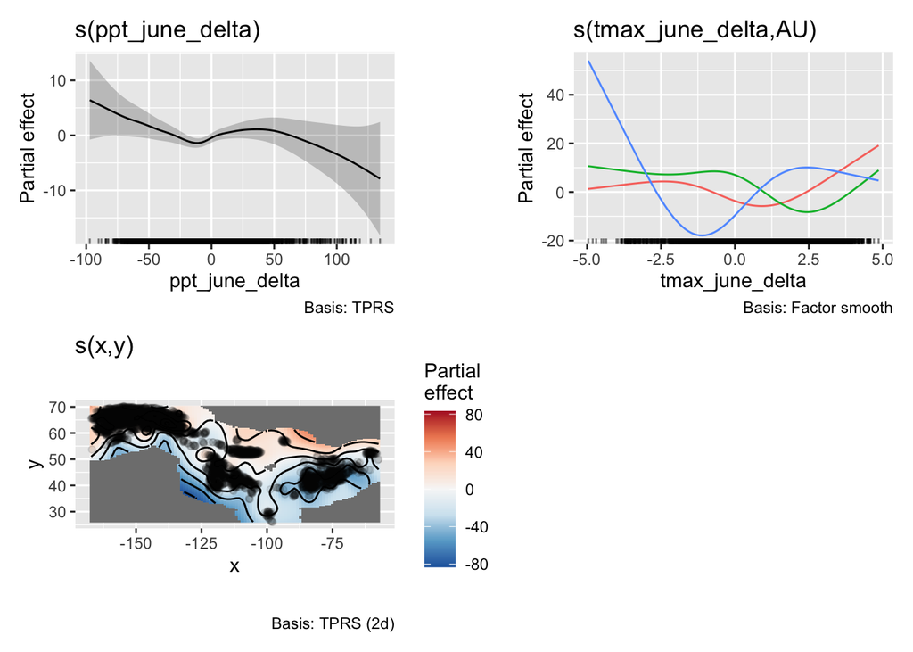

```r
gratia::draw(modS.tmax)
```